# Dial-IncentivesDownsizingValueCreation-1995-JFE.pdf

Converted from PDF `Dial-IncentivesDownsizingValueCreation-1995-JFE.pdf` · 54 pages · anchors: page `#pN`, block `#pN-bK`

Page 1

ELSEVIER Journal of Financial Economics 37 (1995) 261-314

### Incentives, downsizing, and value creation at

### General Dynamics

Jay Dial, Kevin J. Murphy*

Harvard University, Boston, MA 02163. USA

(Received April 1994; final version received July 1994)

Abstract

In 1991, defense contractor General Dynamics engaged a new management team which adopted an explicit corporate objective of creating shareholder value. The com- pany tied executive compensation to shareholder wealth creation, and subsequently implemented a strategy that included downsizing, restructuring, and exit. Paying large executive cash bonuses amid layoffs ignited controversy. However, by 1993 shareholders

realized gains approaching $4.5 billion, representing a dividend-reinvested return of 553%. The study shows how incentives assist in shaping strategy, illustrates the political costs and economic benefits of downsizing and demonstrates that even firms in declining industries have substantial opportunities for value creation.

Key words: Incentives; Compensation; Restructuring; Strategy; Defense industry JEL classijication: G31; G34; G35; 533

1. Introduction

In the post-Cold War era of 1991, defense contractor General Dynamics Corporation (GD) faced declining demand in an industry saddled with current

*Corresponding author.

Data and quotes provided by GD officials are from the teaching case (Murphy and Dial, 1993) which was approved and released by GD management; additional material in this article are from publicly available sources. We are particularly grateful to GD officials Bill Anders, Paul Hesse, Jim Cunnane,

Ray Lewis, and Al Spivak for their time and helpful comments. George Baker, Linda DeAngelo, Myra Hart, Michael Jensen, Scott Keating, Karen Van Nuys, Karen Wruck, and especially Harry DeAngelo (the referee) provided useful comments. Financial support was provided by the Division of Research at the Harvard Business School.

0304-405X/95/.$09.50 0 1995 Elsevier Science S.A. All rights reserved SSDI 0304405X9400803 9

Page 2

262 J. Dial, K.J. Murphy/Journal qf Financial Economics 37 (1995) 261-314

and projected excess capacity. While other contractors made defense-related acquisitions or diversified into nondefense areas, GD adopted an objective of creating shareholder value through downsizing, restructuring, and partial liqui- dation. Facilitating GD’s new strategy were a new management team and compensation plans that closely tied executive pay to shareholder wealth creation, including a Gain/Sharing Plan that paid large cash rewards for increases in the stock price. As GD’s executives reaped rewards amid announce- ments of layoffs and divestitures, the plans became highly controversial, fueling a nationwide attack on executive compensation by politicians, journalists, and shareholder activists. Nonetheless, GD managers credit the incentive plans with helping to attract and retain key managers and for motivating the difficult strategic decisions that were made and implemented: GD realized a dividend- reinvested three-year return of 553% from 1991 to 1993-generating $4.5 billion in shareholder wealth from a January 1991 market value of just over $1 billion.’ In the process, GD returned more than $3 billion to shareholders and debtholders through debt retirement, stock repurchases, and special distribu- tions.

In this clinical study of compensation and strategy at General Dynamics, we examine GD’s compensation system and document its role in determining and achieving GD’s corporate objective. Critics of GD’s compensation system contend that GD’s optimal strategy was obvious and that its managers should have carried out this strategy without high-powered incentives: the reduction in defense spending seemed an inevitable consequence of changing world events, and GD’s CEO was already paid an annual base salary of $800,000 to fulfill his fiduciary responsibility to shareholders. Although the strategic options available to GD were also available to its competitors, GD was the only defense

‘The three-year return of 553% is the return on a share of stock (with reinvested dividends and special distributions) not repurchased in the 1992 Dutch auction. The return to all shareholders over this period (assuming that cash from the repurchase, dividends, and distributions is not reinvested and earns zero returns thereafter) is 426%.

Page 3

J. Dial, K.J. Murphy/Journal of Financial Economics 37 (1995) 261-314 263

Returns assume that dividends and proceeds from repurchases are reinvested. Other defense firms include those listed in Table 7 (excluding General Dynamics). Weights for industry value-weighted returns are l/1/91 market capitalizations.

contractor that responded promptly to the declining world market by taking substantial resources out of the industry. We therefore interpret GD’s perfor- mance (measured relative to the market and industry) as reflecting in large part GD’s incentive systems, its articulated objective of creating value for share- holders, and the vision of GD’s management.

Although some of the $4.5 billion increase in wealth for GD’s shareholders from 1991-1993 reflected either exogenous events in the market or defense industry or GD-specific events not under management’s control, we estimate that between $2.3 and $3.5 billion of the increase was due to actions taken by GD’s managers. Although it is impossible to prove that GD’s incentive system ‘caused’ these wealth-increasing actions, we present evidence that the system provided meaningful incentives to undertake particular actions, that these actions were taken, and that the managers themselves believe that GD’s restruc- turing and ultimate downsizing could not have been accomplished without the incentives in place.

Viewing this clinical study in a broader context, GD’s situation is similar to that confronting firms in other industries characterized by excess capacity, such as automotive, retail trade, steel, and computers. Excess capacity in the

Page 4

264 J. Dial, K.J. Murphy/Journal of Financial Economics 37 (1995) 261-314

defense industry is related to the Reagan-era build-up and the post-Cold War downsizing, while in other industries excess capacity arises from changes in technology and demand, deregulation, increases in global and nonunionized competition, and managers’ tendency to overinvest in growth. Economic effi- ciency suggests that human as well as physical capital should be transferred from industries with excess capacity to alternative sectors. Few managers, however, have been able to accomplish the necessary resource redirection until their organizations face crises in the product, factor, or capital markets (Jensen, 1993). Even though GD’s situation is replicated in many firms and industries, its response and ultimate achievements are remarkable, and serve as perhaps the preeminent management and shareholder success story of the early 1990s. The paper proceeds as follows: Section 2 offers a conceptual framework relating to the importance and difficulty of providing appropriate managerial incentives in industries saddled with excess capacity. In Section 3, we describe the compensation policies and strategic initiatives at GD under CEO Anders, and examine the political consequences of GD’s Gain/Sharing Plan. The data presented were obtained from public sources and from discussions with Anders and other GD executives during 1993. Section 4 contrasts GD’s strategy and incentives with those adopted by other major defense contractors. We show that, although other contractors also espoused and eventually adopted consoli- dation and downsizing, GD’s response in moving resources out of the industry was significantly quicker and more dramatic than its competitors. In addition, we show that GD had substantially more stock-based incentives than the average of other firms in the industry or in the S&P 500. Section 5 analyzes the source of GD’s value gain, and examines several of the criticisms and concerns relating to GD’s compensation and strategy voiced by politicians, academics, shareholder groups, and the media. Section 6 concludes.

2. Value creation and incentives in tbe defense- industry

Excess capacity in an industry implies that increased investment in the industry earns less than the cost of capital, and therefore destroys value for shareholders and for society. However, excess capacity offers important oppor- tunities to create value even in the absence of profitable investment opportuni- ties. In particular, creating value under excess capacity involves diverting resources from activities that earn less than the cost of capital (Stewart, 1991), which in turn implies transferring human as well as physical capital from industries with excess capacity to alternative sectors. Stock repurchases, divi- dends, special distributions, and cash acquisitions within an industry create value under excess capacity by paying out cash to shareholders rather than spending it unproductively (Jensen, 1986). Similarly, workforce reductions through layoffs and attrition create value by facilitating the transfer of workers

Page 5

J. Dial, K.J. Murphy/Journal of Financial Economics 37 (1995) 261-314 265

to sectors where their skills and effort are more highly valued by society. The transfer of human resources, unfortunately, often imposes real costs on rede- ployed workers-especially in the short run- but is nonetheless an efficient and necessary response to excess capacity. Moreover, as we discuss below in Sec- tion 5, the fact that redeployed workers earn lower wages in alternative sectors does not necessarily imply that implicit contracts have been breached or that wealth has been transferred from workers to shareholders.

The end of the Cold War and the resultant decline in the demand for major weapons platforms generated excess capacity among defense contractors. As- suming that the demand shift is permanent, the economically efficient response is to move both human and physical capital from the defense sector to alterna- tive higher-valued uses. Market pressures will inevitably force resources out of the defense industry in the long run. In the shorter run, however, many defense firms can maintain their current production with only small declines in employ- ment and investment. Major defense contractors typically maintain large ‘back- logs’ of current orders for future deliveries: GD’s 1990 backlog, for example, was $23 billion. Profit margins on these backlogs are sufficiently high to guarantee large cash flows and solvency for several years. Many defense contractors also have large nondefense-related businesses that can subsidize inefficient resource utilization in defense businesses. Alternatively, nondiversified defense con- tractors can use current cash flows to diversify gradually by retraining their workforce to produce nondefense products or by acquiring nondefense businesses. Yet another strategy-rational for an individual defense firm but not viable for the industry as a whole-is to enhance the probability of surviving the impend- ing shake-out in the global defense industry by investing and growing in the defense area.

Traditional executive incentive packages-characterized by high base salaries, accounting-based bonuses, and low levels of stock ownership (Jensen and Murphy, 1990)-do not provide effective incentives to downsize. These tradi- tional pay practices may work well in strong growth economies where the actions that create size and growth are closely correlated with the actions that create value (Baker, 1992). These same practices, however, provide incentives for continued growth even when it is not warranted by the market, and thus have contributed to excess capacity in many industries. There are several reasons why managers paid under traditional systems are unlikely to adopt downsizing strategies even when these strategies produce the highest benefits for shareholders and society:

1. Managerial compensation is typically tied to firm size and/or span of control. Economic theory predicts that CEO compensation will increase with firm size only to the extent that size is a proxy for the skills and abilities required for the position (Rosen, 1982). The pay-size relation has been institutional- ized, however, by widely utilized compensation surveys that use size as the

Page 6

266 J. Dial, K.J. Murphy/Journal of Financial Economics 37 (1995) 261-314

2.

primary, if not the only, determinant of pay levels (Baker, Jensen, and Murphy, 1988).

Managerial compensation is typically tied to short-run accounting profits (Healy, 1985). Downsizing often involves large restructuring charges that reduce accounting profits in the short run.’ Encouraging voluntary attrition through early retirement, severance programs, and retraining programs also increases current expenses, thereby decreasing current accounting profits. In

addition, gains associated with sales of plants or divisions are often not included in net income. Thus, managers pursuing downsizing strategies will realize immediate reductions in their annual accounting-based bonuses.

3. Nonmonetary compensation- including power, prestige, and community standing- tends to be linked to firm size and survivability and not to wealth creation. Managers involved in downsizing and layoffs will be subject to media criticism and loss of community standing.

4. Laying off employees and leaving communities is personally painful for managers (particularly those with long company tenures). It is relatively easy to provide incentives for growth: Managers intrinsically enjoy opening new plants, hiring new workers, and announcing new investment programs. In contrast, few managers enjoy downsizing: it’s simply less fun than growing.3

In addition, affected employees and communities impose large nonpecuniary costs on managers, which further reduces the managers’ incentives to down-

size.

5. Managers often embrace survival and not value creation as the ultimate objective of the organization (Smale, 1989). Many managers don’t under- stand and too easily dismiss exit as an appropriate long-term strategy for an organization, even when this strategy creates the most value for shareholders and society. Managers focused on corporate survival will resist exit and pursue costly and inefficient diversification into product lines where they have no expertise or competitive advantages.

6. Moving resources out of an industry reduces the value of managers’ indus- try-specific human capital, and may ultimately cost managers their own jobs.

The tendency for managers to resist downsizing and restructuring highlights both the difficulty and importance of providing appropriate incentives in the defense industry and other industries with excess capacity. Resistance to down-

ZDechow, Huson, and Sloan (1994) present evidence that compensation committees may implicitly adjust accounting-based bonuses for the negative consequences of restructuring charges.

%ee, for example, ‘The Pain of Downsizing’, Business Week, May 9, 1994.

Page 7

J. Dial, K.J. Murphy/Journal of Financial Economics 37 (1995) 261-314 261

sizing can be mitigated by explicitly adopting a corporate objective of creating shareholder value, and by tying managers’ wealth to shareholder value cre- ation-not to size, employment, accounting profitability, or survival. Stock- based incentives-such as stock options, restricted stock, stock ownership, and compensation plans tied to stock prices rather than profits-are natural ways to reward value creation. Because the decision to downsize and transfer resources from an industry is made at the top of the organization, stock-based compensa- tion can be concentrated among top managers, and not diluted by pushing incentives throughout the organization.4 Bringing in managers from outside the firm may also be appropriate: outside managers have weaker personal relation- ships with employees, customers, suppliers, and communities affected by work- force reductions, and the loss of firm-specific capital associated with outside hires is less important under downsizing and exit strategies. Spinning-off unre- lated subsidiaries and avoiding new diversification can mitigate cross-subsid- ization tendencies. In the following sections, we show how GD followed these prescriptions, creating nearly $4.5 billion in shareholder wealth in the process. The hypothesis that stock-based incentives are most important in declining industries with little potential for future growth appears counter to Smith and Watts (1993), Gaver and Gaver (1993), and others who argue that stock-based incentives are most important in companies with growth opportunities, based on the premise that managerial discretion is more important in growing indus- tries. But, managerial discretion is important in declining industries such as defense as well as in growing ones: there can be significant opportunities to create wealth even when there are few opportunities to create growth. Moreover, under the hypothesis that managers will naturally pursue growth opportunities but will resist downsizing, it is more important to provide financial incentives to downsize than to provide incentives to grow.

3. Compensation and strategy under CEO William Anders

3. I. Company background

General Dynamics began in 1899 as the Electric Boat Company and became a major supplier of submarines and cargo ships to the U.S. Navy during both World Wars. Following World War II, the company adopted a strategy of building the ‘General Motors of the weapons industry’ through acquisition, diversification, and internal development. By 1960, the company was a major aircraft, booster rocket, and missile manufacturer, and dominated the nuclear

4Downsizing or exit strategies may be unique in this respect: most strategies require ‘buy-in’ from

lower-level employees which in turn requires some form of incentive compensation at lower ranks.

Page 8

268 J. Dial, K.J. MurphyJJournal of Financial Economics 37 (1995) 261-314

submarine business. The company was renamed General Dynamics Corpora- tion to reflect the firm’s diversified defense operations.

GD continued to grow and expand during the next three decades, establishing itself as the only defense contractor to supply major weapons systems to all three branches of the U.S. military. GD also expanded into foreign sales. Its F-16 jet was adopted as the preeminent lightweight fighter jet by the U.S. Air Force and several foreign countries. GD’s Electric Boat division expanded its dominance of the nuclear submarine business; its Convair division added the ‘Tomahawk’ sea-launched cruise missile to its arsenal of standard missile products. During the early 198Os, GD bought Chrysler’s M-l ‘Abrams’ and M-60 tank business and acquired Cessna, a leading manufacturer of civilian aircraft. GD also became involved in several major fracases with the federal govern- ment. While GD steadfastly denied accusations of illegal actions (ranging from faulty workmanship to fraudulent claims and illegal gifts), the firm was barred by the Navy for a brief period from receiving new contracts. Unfavorable press coverage damaged GD’s public image. Although GD remained profitable throughout the 198Os, continuing profitability was threatened in the latter half of the decade by changes in the government’s procurement practices, including more dual-source supply, lower progress payments, and greater focus on price competition and fixed-price contracts.

3.2. GD hires Anders as vice chairman

On September 27, 1989 GD announced the hiring of William A. Anders as its next Chairman and Chief Executive Officer. The 55-year-old Anders, hand- picked by CEO Stanley Pace, agreed to join GD as vice chairman on January 1,

1990 and succeed Pace as Chairman and CEO at his retirement on January 1, 1991. Anders was a former Air Force pilot and Apollo 8 astronaut who orbited the moon on Christmas 1968. He had served as executive secretary of the National Aeronautics and Space Council in Washington (1963-72), commis- sioner of the Atomic Energy Commission (1973-74), head of the Nuclear Regulatory Commission (197576), and Ambassador to Norway (1976-77). In 1977, he joined General Electric as general manager of its nuclear energy products division and then its aircraft equipment division. In 1984, Anders was named senior executive vice president for operations at Textron, a Rhode Island-based conglomerate. He headed Textron’s defense businesses as well as several consumer products lines.

According to Anders, one of the chief concerns in his contract negotiation was assuring his independence from GD’s largest shareholder, the Crown family. Although the Crowns were not directly involved in selecting or recruiting Anders to GD, they had established a reputation for influencing CEO employ- ment decisions. Self-made millionaire Henry Crown originally gained control of three GD board seats in 1959 as the result of the merger between GD and

Page 9

J. Dial, K.J. Murphy/Journal of Financial Economics 37 (1995) 261-314 269

Crown’s Material Service Corporation. In 1962, following GD’s disastrous foray into manufacturing commercial airliners, Crown ousted the CEO. In 1966, Crown lost a boardroom power struggle with his personally selected CEO, and was forced to sell his shares and leave the board. Just three years later, Crown and his allies quietly accumulated 18% of GD’s common stock, and Crown effectively regained control of the corporation. Once again he replaced the incumbent CEO. Although Henry Crown died in late 1990, three representatives of the Crown family remained on GD’s board of directors, including corporate Executive Vice

President Lester Crown. As of February 1991, the Crown family held over nine million shares of GD stock-about 22% of the 41.9 million outstanding shares (see Appendix A). Anders viewed the existence of a major shareholder as an obstacle rather than a benefit. Anders reflected on the contract negotiations:5

I negotiated a great contract because I wanted total independence. I realized the risk involved in working for a large shareholder [the Crown family] and I wanted to be independent from that risk. First, I wanted GD to make me whole from what I was giving up at Textron. Then, I wanted an agreement so that I would be able to retire on the day I walked in here. That is the kind of independence I wanted so that I could make the changes that were needed and I would not have to be looking over my shoulder at the big shareholder.

Corporations hiring CEOs from other firms often pay ‘sign-on bonuses’ to compensate for lost benefits: For example, IBM paid Louis Gerstner $5 million for benefits he lost at RJR Nabisco, and Kodak paid George Fisher $5 million for benefits lost at Motorola. An interesting difference in Anders’ case is that his

-

5Unless otherwise sourced, quotes from Anders are from the teaching case (Murphy and Dial, 1993)

and are based on a personal interview conducted in April 1993.

6The number of restricted shares granted was based on the amount Anders would have received if he

had stayed at Textron (which in turn depended on Textron’s performance): Anders’ received 13,740

shares, 16,586 shares, and 4,614 shares in 1990, 1991, and 1992 respectively.

Page 10

210 J. Dial, K.J. MurphyJJoumal of Financial Economics 37 (1995) 261-314

sign-on bonus was paid in GD stock options and restricted stock, rather than in cash. This stock-based sign-on bonus also ensured that Anders’ option and stockholdings would approximate those of his predecessor, Stanley Pace.

3.3. Company and industry outlook upon Anders’ appointment

Anders spent 1990, his first full year with GD (but before he became CEO), undertaking a comprehensive assessment of the company’s strategy, its opera- tions and markets, and its financial structure. Realizing that it was no longer ‘business as usual’, he quickly concluded that GD was heading towards serious financial trouble. GD’s monthly closing stock price had fallen from a high of $79 in February 1987 to $25.25 at the end of 1990; accounting returns had also declined over the same time period. The company absorbed a $578 million net loss in 1990 (on $10.2 billion in sales). These losses were driven by over $1.3 billion in unusual charges, including $700 million in write-offs over its troubled A-12 Navy attack jet program. GD announced 8,500 layoffs in 1990, and both Moody’s and S&P downgraded the firm’s debt ratings, citing its weak financial condition. In December 1990, the Pentagon announced that its audits revealed GD to be in ‘weak’ financial condition with ‘ . . . a possible chance for bank- ruptcy?

World events in 1989 and 1990 had profound implications for the entire U.S. defense industry. In 1989, the U.S.S.R. completed its withdrawal from Afghanistan, allowed Poland’s first free elections, and saw Soviet-backed re- gimes fall in Hungary, East Germany, Czechoslovakia, Bulgaria, and Romania. In November 1989, the Berlin Wall fell. During 1990, Germany was reunified and the Soviet Union distintegrated. In November 1990, U.S. President George Bush and Soviet President Mikhail Gorbachev, along with other leaders from NATO and the Warsaw Pact, announced the official end of the half-century-old Cold War, promising ‘a new era of democracy, peace, and unity’. Arms-control agreements between the U.S. and the (former) Soviet Union dramatically re- duced the current and projected future demand for major defense platforms. The prospects for peace carried particularly harsh ramifications for GD: While other major defense contractors had diversified operations outside of the defense industry, GD received more than 80% of its revenues from the Pentagon.

Anders believed that the collapse of the Soviet Union and the end of the Cold War signaled a watershed in defense funding that would permanently affect GD’s market opportunities. This conclusion was reached, in part, by analyzing patterns of U.S. defense spending during wartime and peacetime since 1900, which suggested that Cold War defense spending levels were an aberration not

‘David J. Jefferson and Andrew Pasztor, ‘Pentagon Audits Show Contractors Owe U.S. Hundreds of Millions in A-12 Job’, Wall Street Journal, December 19, 1990.

Page 11

J. Dial, K.J. Murphy/Journal of Financial Economics 37 (1995) 261-314 271

sustainable in ‘true’ peacetime. Anders’ prediction of future cuts was supported by federal projections released in early 1991. While the 1991 federal budget authorized $86 billion in procurement spending, the 1992 federal budget (delivered to Congress in January 1991) had revised the 1991 and 1992 budget authority for procurement downward to just $64 billion and $63 billion, respec- tively.8

3.4. Anders ’ early initiatives as CEO

Anders took office as Chairman and CEO on January 1, 1991, and his explicitly stated goal was to transform GD into a shareholder-driven enterprise. He sought to improve company financial performance by maximizing margins from its $23 billion backlog, increase returns, and generate a sharper focus on investments through higher margins, better progress payment rates, and higher hurdle rates. In order to facilitate these operational changes, Anders believed he needed to bring in a new management team, fundamentally alter the corporate culture, and institute compensation systems for the top management team that more closely tied pay to shareholder wealth creation.

In spite of the planned reductions in government spending and the warning signals emanating from within GD, Anders faced a major hurdle in convincing his board of directors and existing top managers that GD was, indeed, heading for a crisis. He found that most of the managers at GD (and at other defense firms as well) believed they could maintain the status quo and survive the impending shake-out in the defense industry. Anders brought in a Wall Street analyst to alert the top managers and directors to the severity of GD’s situation. The analyst noted that GD’s price-earnings ratio ranked 497 in the S&P 500. In his ensuing discussions with directors, Anders stressed the need to build a new management team, but emphasized the difficulty of attracting, retaining, and motivating managers in the declining defense industry. Soon after Anders’ appointment as CEO, GD made wholesale management changes at its upper echelons. Eighteen of the top 25 executives were either new to GD or new to their positions. Anders promoted Executive Vice President James Mellor (who had been in charge of submarines, tanks, and overseas sales)

to president and chief operating officer. Anders and Mellor were members of GD’s board of directors, which included five top managers, two former Chairman/CEOs, and nine outside directors (see Appendix A).

sProcurement appropriations of the Department of Defense finance the acquisition of weapons,

equipment, munitions, spares, and modifications of existing equipment. Budget authorityfor procure-

ment includes appropriations for the year enacted as well as spending which is earmarked for future

years. Actual spending (which includes budget authority for the year enacted in addition to

appropriations carried over from prior years) was estimated at $79 and $74 billion for 1991 and

1992, respectively; actual spending was projected to fall to $67 billion by 1994.

Page 12

212 J. Dial, K.J. Murphy/Journal of Financial Economics 37 (1995) 261-314

Mellor was in charge of operationalizing Anders’ objective of creating wealth for shareholders. An industry analyst lauded the Anders-Mellor team: ‘Anders provides the cold, calculated decision-making needed at the strategic level, and Mellor is very good at getting a lot of people rowing together in the right direction’.’ Anders commented on Mellor’s role:

We talked a lot about focusing on shareholder value and each of our top executives was committed to this objective. Even though that was our focus, it was not our strategy because ‘maximize shareholder value’ is difficult to operationalize.

Mellor really helped the managers understand how to run their businesses. Just accepting the idea of shareholder value isn’t enough. For a lot of the managers, it was a case of ‘OK, I believe in shareholder value, but what should I do tomorrow?’ Mellor taught them how to manage for cash.

Anders’ new business plan called for dividing the company into business areas and pushing decision-making authority further down into the hierarchy. To assist its managers in adjusting to their expanded responsibilities amid the company’s new business approach, GD commissioned Northwestern Univer- sity’s Kellogg School of Management to develop a special one-week seminar for 150 of its top managers. According to Anders, the intensive training sessions focused on teaching business basics and investment analysis so that GD’s managers would ‘ . . . think like business people, not like aerospace engineers’.

3.5. Executive compensation at General Dynamics

Anders sought to focus his management team on maximizing shareholder value. He describes the company’s approach:

When we started to build a new management team, we wanted partners, not high salaried people. We needed to attract good people from outside and to entice good insiders to change to different divisions. These managers came here for about the same salaries they had been making, but they needed additional inducements because their careers were riskier at GD. To attract good people and then to change behavior, you have to compensate them well.

I didn’t want to take the company private, but I wanted a private-company mentality. I wanted to break out of the ‘hired hand’ mentality. There is an enormous difference between being a smart hired hand and being a partner.

‘Anthony L. Velocci, Jr., ‘General Dynamics Shakeup Aims for Solid Fiscal Footing’, Aviation Week

& Space Technology, August 5, 1991.

Page 13

J. Dial, K.J. Murphy/Journal of Financial Economics 37 (1995) 261-314 213

They brought me in as a hired hand and I changed it to a partnership arrangement. I wanted to develop a management/shareholder partnership and create an environment where there was no doubt in anyone’s mind about what we were here to do: create shareholder value.

In addition to defining the corporate objective and building a new and better-trained management team, Anders decided it was crucial for GD’s execu- tive compensation policies to provide meaningful and appropriate incentives for its top-level managers. GD’s existing compensation packages included base salaries, bonuses tied to the company’s accounting return on equity, and stock options. Anders felt that relying on accounting-based bonuses provided inap- propriate incentives for a shareholder-value-focused company requiring dra- matic changes in its strategy and culture. Furthermore, the outstanding stock options-granted in prior years at exercise prices far exceeding the current stock price-also failed to provide meaningful incentives. Under Anders’ recommendation to the compensation committee, approxim- ately 25 top executives would earn cash ‘Gain/Sharing’ bonuses for improve- ments in the stock price, 150 upper-level executives would receive accelerated stock option and restricted stock grants, and 1,150 managers and executives would be eligible to participate in an ‘option exchange’ program in which previously granted options could be exchanged for new options at a lower exercise price. The proposal also included changes in the company’s savings and investment plan (SIP) to encourage lower-level employees to hold GD stock (approximately 62,000 employees). These proposals were accepted (with minor modifications) by the four outside directors who comprised the compensation committee, approved by the full board of directors on February 15, 1991, and approved by shareholders at the May 1, 1991 annual meeting.

3.5.1. Incentives, bonuses, restricted stock, and stock options At its February 15, 1991 meeting, the committee approved approximately 1.6 million shares of stock option awards in addition to bonuses of $19 million in cash and restricted stock for the 1,150 eligible employees. Table 1 shows the base salaries, bonus awards, and 1991 restricted stock and stock option awards. Each option, exercisable beginning August 1992 and expiring in February 2001, gave the recipient the right to buy one share of common stock at an exercise price of $25.5625 (the market price on the February 15 grant date). Shares of restricted stock vested over time: 40% became unrestricted four years after the grant date, and thereafter at a rate of 10% per year, contingent on continued employment. In accordance with Anders’ proposal to accelerate option and restricted stock grants for the company’s top 150 executive officers, option grants were approximately three times the normal annual award for each individual, and the committee ‘promised’ that a similar number of restricted shares would be awarded in 1992 and 199.3. In contrast to typical restricted

Page 14

Table 1

Salaries, bonuses, restricted stock, and stock options awards approved by General Dynamics compensation committee on February 15, 1991

Incentive awards granted in February 1991

Executive

William Anders

Chairman/CEO

James Mellor

President/COO

Lester Crown

Executive VP

1991 base 1991 cash

salary bonuses”

$800,0000 S500,OOO

$650,000 $300,000

$303,000 $200,000

Restricted stock

Shares Shares

grantedb promised’

20,850 44,910

15,000 30,OQO

5,550 13,250

. . . . . . . . . . . .

Executive officers

as a group’

Other participants

All participants

$9,416,100 $2,632,000 94,260 253,410

$11,371,749 93,880 150,450

. . . . . . . . . . . . . . . . .

$14,009,749 188,140 403,860

|  |  |  |  | Incentive awards | granted in February | 1991 |  |  |  |  |
| --- | --- | --- | --- | --- | --- | --- | --- | --- | --- | --- |
|  |  |  |  |  | Restricted stock |  |  |  | New options | Total |
|  |  |  |  |  |  |  |  | Number | acquired by | options after |
|  | 1991 base |  |  | 1991 cash | Shares | Shares |  | of stock | exchanging | new grants |
| Executive | salary |  |  | bonuses” | grantedb | promised’ |  | optio& | old options | and exchange |
| William Anders | $8000000 , |  |  | S500OOO , | 20850 , | 44910 , |  | 219880 , | 51479 , | 271359 , |
| Chairman/CEO |  |  |  |  |  |  |  |  |  |  |
| James Mellor | $650000 , |  |  | $300000 , | 15000 , | 30OQO , |  | 120000 , | 13613 , | 133613 , |
| President/COO |  |  |  |  |  |  |  |  |  |  |
| Lester Crown | $303000 , |  |  | $200000 , | 5550 , | 13250 , |  | 48500 , | 11862 , | 60362 , |
| Executive VP |  |  |  |  |  |  |  |  |  |  |
| . . . . . . . . . . . . | . | . . . . . | , | . . . . | . . . . . . . . . . . . . . . . | I . . . | . . |  |  | . . . |
| Executive officers | $9416100 , , |  |  | $2632000 , , | 94260 , | 253410 , |  | 829350 , | 249206 , | 1078556 , , |
| as a group’ |  |  |  |  |  |  |  |  |  |  |
| Other participants |  |  |  | $11371749 , , | 93880 , | 150450 , |  | 134230 , | 288556 , | 1022786 , , |
|  |  |  |  | . . | . . . . . | . . . . . . . . . | . |  |  |  |
| All participants |  |  |  | $14009749 , , | 188140 , | 403860 , |  | 1563580 , , | 537762 , | 2101342 , , |

NOTE: table converted from PDF layout to HTML text; cell boundaries are reconstructed. See PDF if exact alignment matters.

Source: March 1991 and December 1991 proxy statements.

“Some cash awards (including $180,000 to Mr. Crown) made in unrestricted shares of common stock.

bRestricted stock awards given at the fair market price of $25.5625. Some awards of executives other than those listed made on March 5, 1991, at a market

price of $24.3125.

‘Restricted stock awards promised for 1992 and 1993. These shares were ultimately conveyed in December 1991

dOptions granted at an exercise price of $25.5625. Some options for executives other than those listed were granted on March 5, 1991, at an exercise price

of $24.3125.

‘Amounts based on 36 executives for 1991 base salary (from December 6, 1991 proxy statement) and 29 executives for incentive awards (from March 28.

1991 proxy statement).

Page 15

J. Dial, K.J. MurphyJJournal of Financial Economics 37 (1995) 261-314 275

stock awards in which the manager receives a fixed dollar value of stock each year, GD’s fixed-share promise means that those shares start providing incen- tives in 1991, years before they are conveyed.

Although it is common for companies to reprice options following declines in stock prices, CD’s option exchange program was unusual because it yielded repriced options at no additional cost to shareholders. [We note that by reducing the number of options upon exchange, GD’s exchange program was ‘acceptable’ according to the criteria outlined in Crystal and Foulkes (1988).] Anders’ financial incentives to increase stock prices declined, however. Prior to the exchange, each $1 increase in GD’s stock price (from $25.5625) increased the

Black-Scholes value of Anders’ 103,746 old options by $39,000, compared to an increase of only $28,000 for his 51,479 new options. Moreover, based on the subsequent increase in GD’s stock prices to ($142 by year-end 1993, including special distributions) Anders’ participation in the exchange program personally cost him more than $4 million ex post.

3.5.2. The Gain/Sharing Plan The most unusual and ultimately controversial part of the compensation program proposed by Anders and approved by the compensation committee at the February 15 meeting was the Gain/Sharing Plan. In contrast to typical bonus plans based on accounting performance, GD’s plan was based on stock- price performance, awarding cash bonuses for each $10 increase in the com- pany’s stock price (representing a $417 million increase in shareholder value). Under the program, GD’s top executives would receive a bonus equal to 100% of their base salaries if GD’s stock price closed at or above $35.5625 (i.e., $10 above the February 15 price) and stayed at or above this level for ten

Page 16

276 J. Dial, K.J. Murphy/Journal of Financial Economics 37 (1995) 261-314

consecutive trading days. For each subsequent $10 increase sustained for ten consecutive trading days, the executives would receive additional bonuses equal to 200% of their base salaries.

The 25 executives- with combined base salaries of $6.3 million- who ulti- mately participated in Gain/Sharing would receive approximately 1.5% of the increase in shareholder value for the first $10 increase, and 3% for subsequent $10 increases in GD’s stock price. There was no limit on the number of bonuses as long as the stock price continued to climb. The expiration date of the program was February 15, 1994. Half of each award was to be deferred until retirement; the other half would be paid in cash, although the amount could be deferred at the recipient’s request. The deferred portion would accrue interest at a rate of five percentage points above the prime interest rate (or Moody’s corporate bond rate, if higher). At the committee’s discretion, the interest rate would be reduced if the firm’s share prices fell below certain levels in the days immediately following announcements of company earnings. Executives participating in the committee’s proposed Gain/Sharing Plan included Anders, Mellor, CFO James Cunnane, nine corporate vice presidents responsible for functional business performance, four operating group executive vice presidents, and several division and business-area heads. Executive Vice President Lester Crown endorsed the plan but voluntarily elected not to participate. Anders conceived of the Gain/Sharing Plan as a means to institute his ‘partnership’ approach to the management of the firm. Anders, who believed GD’s stock price could climb to at most $45 by 1994, described the initial discussions with the board on the Gain/Sharing initiative:

Keep in mind that originally it didn’t look like there was that great an upside. When we developed and presented it to the Board, I originally asked to be left out of it. I felt somewhat uncomfortable including myself in the plan that I had conceived. However, the Board wouldn’t hear of a plan in which I didn’t participate.

Anders confided that GD honestly hadn’t much thought about the appro- priateness of the ten-day window; it was recommended by compensation com- mittee chairman Elliot Stein, who had employed a similar window in a plan at Ralston-Purina.”

3.5.3. Savings and stock investment plan To encourage a partnership mentality among lower-level employees, Anders recommended, and the compensation committee approved, charfges in the

“In the Ralston-Purina plan, the CEO received a large grant of restricted stock for achieving a stock price of $100 for ten days. The plan was ultimately controversial, not because of the ten-day window but rather because the $100 hurdle was met during a period in which the company was

underperforming the industry and market (Campbell and Wasley, 1994).

Page 17

J. Dial, K.J. Murphy/Journal of Financial Economics 37 (199.5) 261-314 217

company’s Savings and Stock Investment Plan (SIP), which covered approxi- mately 62,000 employees. Prior to 1991, the company contributed 75# for each $1 invested by the employee and allowed employees to designate how the company’s contribution was invested. Under the new plan, GD would match employees dollar-for-dollar for investments in the company’s common stock while the company’s contribution would be only 50# for every dollar placed in any investment other than the GD common stock fund. Prior to the introduction of the new SIP, 20,600 GD employees held 3.7 mil- lion shares of company stock. This represented 23% of GD’s employees and 8.8% of the shares outstanding. By June 1991, the number of employees participating in the program jumped to 48,300 (54%) and the shares held by these employees increased to 4.3 million (10.3%). By June 1992, employees held 6.2 million shares, representing almost 15% of the shares outstanding.

3.6. General Dynamics under William Anders, 1991

After Anders was named CEO on January 1, 1991, he moved swiftly to streamline operations and improve profitability. Consistent with his belief that increased expenditures in the defense industry were inefficient, Anders reduced GD’s capital expenditures to $82 million in 1991 from $321 million in 1990 and $419 million in 1989. Similarly, R&D spending was cut to half of the $390 mil- lion spent in 1990. GD also emphasized reductions in inventories and working capital in order to reduce costs and improve returns. A chronology of GD events from 1991 through 1993-including three-day industry and market-relative stock-price reactions surrounding each event-is reported in Appendix B. As described in this Appendix, GD’s stock fell to about $20 early in 1991 when the Navy’s A-12 jet fighter program was canceled. Soon after, the United States and 27.other nations joined in Operation Desert Storm, the military response to Iraq’s August 1990 invasion of Kuwait. The air war began on January 17, and the four-day ground war ensued on February 24. GD’s marquee products (‘Tomahawk cruise missiles, F-16 fighters, and M-l ‘Abrams’ tanks) performed spectacularly, but Anders discounted the long-term effect on firm profitability, arguing that the war’s cost would ultimately reduce development budgets for new weapons.’ ’ In early February 1991, the federal government allowed GD and McDonnell Douglas to delay repayment of $1.4 billion in unliquidated progress payments made on the canceled A-12. The companies claimed that repayment would cause extreme financial pressures. Later that month, following the February 15 board

“William Saporito, ‘America’s Arsenal: This War Doesn’t Mean a Windfall: General Dynamics’, Fortune, February 25, 1991.

Page 18

278 J. Dial, K.J. Murphy/Journal of Financial Economics 3 7 (I 995) 261-3 I4

Daily stock prices from Dow Jones News Retrieval and Compustat. GD-related events from company press releases, analyst reports, and the Wall Street Journal. Industry and S&P 500 prices are determined by appreciating GD’s January 1, 1991 price by the cumulative returns on the industry and S&P 500 portfolios.

‘*Alexandra Peers, ‘Some Insiders, Bucking Trend, Buy Stock’, Wall Street Journal, April 10, 1991.

Page 19

J. Dial, K.J. Murphy/Journal of Financial Economics 37 11995) 261-314 219

jet fighters, reversing a prior award to McDonnell Douglas for their F-18 fighter and pushing GD’s stock price up 7%.13

On April 23, the federal government selected the team led by Lockheed, which included GD and Boeing, to build the Air Force’s next generation advanced tactical fighter (ATF). The program was expected to generate $60 billion in revenues for the companies. Following the announcement, GD’s stock closed up 6.4% to $36.875, surpassing the Gain/Sharing hurdle of $35.5625.

3.61. The first Gain/Sharing payofs On May 1, a majority of shareholders (78%) voted their approval of the new Executive Compensation Program, which included the Gain/Sharing provi- sions. The same day, GD’s President Mellor made an announcement widely interpreted as predicting massive layoffs at the defense giant: ‘Our current workforce is just over 90,000 employees. In response to the decline in the defense market, present projections indicate that this may be reduced by about 30% over the next four years.’ GD’s stock price closed at $39, up over 3%. Just five days later, on May 6, GD’s stock closed above $35.56 for the tenth consecutive trading day, triggering $5.1 million in Gain/Sharing bonuses for 19 executives. The next day, Anders bought another 5,000 shares at $39.50.

The announcement of the bonuses within a week of shareholder ratification drew howls of protest. Business Week dubbed the company ‘Generous Dynam- ics’, and quoted a Pentagon official warning Anders not to bill the ‘outrageous’ compensation to government contracts. The media was particularly harsh to former outside director and compensation committee member Harvey Kapnick, who qualified for inclusion in the bonus plan when he was named vice chairman in April 1991.14 His cash bonus was prorated for the difference between GD’s

$33.50 average share price on the day he began work (April 15) and the closing price on May 6; thus, Kapnick received a Gain/Sharing bonus equal to 20.625% of his $600,000 salary, or $123,750.

13Rick Wartzman and Damon Darlin, ‘South Korea, in a Reversal, Picks F-16 Jet’, Wall Street

Journal, March 29, 1991, p. A3.

14James E. Ellis, ‘More Cash than a Lottery’, Business Week, May 20, 1991, p. 42.

Page 20

280 J. Dial, K.J. MurphyJJournal of Financial Economics 37 (1995) 261-314

Two days later, Anders addressed Morgan Stanley’s Aerospace/Defense and Multi-Industry Conference and made two startling announcements. First, he dismissed diversification as a viable strategy for GD, citing a McKinsey study that claimed an 80% failure rate for nondefense acquisitions by defense con- tractors. Second, he predicted that cash flows would be in excess of that required to fund the firm’s current liquidity and investment needs. He suggested returning ‘excess’ cash to shareholders using unspecified methods that might include stock buybacks, increased dividends, special distributions, or self tenders. These an- nouncements- which the Washington Post, citing Anders’ potential bonus, dubbed ‘the $1.6 million speech’-caused the stock price to jump $7.75 over two days (reflecting an industry-adjusted increase in shareholder wealth of $343 mil- lion), rocketing past the Gain/Sharing bonus target and closing at $49.50. Ten trading days later, October 8, GD announced a second Gain/Sharing payout of $12.6 million (200% of the top managers’ base salaries), bringing the total payout to the 25 participants in the plan to almost $18 million (or about 2.1% of the $833 million increase in GD’s market value). Both Gain/Sharing payoffs generated widespread criticism among politicians, labor unions, GD employees, and shareholder groups. For the most part, shareholder groups voiced concerns about the mechanics of the plan, question- ing in particular the appropriateness of the ten-day window. Criticism from other sectors focused on the political ‘incorrectness’ of paying large cash bonuses amid announcements of layoffs and downsizing.

3.63. Reaction to Gain/Sharing’s ten-day window Gain/Sharing’s ten-day window prompted criticism that managers would make announcements or take actions that increase short-term, but not long- term, stock prices. For example, Howard Sherman, vice president of Institu- tional Shareholder Services, argued that ‘ . . . a ten-day plateau is nowhere near a good measure of long-term success’. l5 Institutional proxy advisor Anne Faulk agreed, calling the plan ‘ . . . a bastardization of a good idea. Ten days just isn’t a very long time, and you won’t see management’s salaries going down when the share price falls’.’ 6

Although managers may be able to manipulate prices in the very short term by deliberately misleading analysts and investors, there is no evidence that Anders ever attempted to mislead investors: indeed, the ‘$1.6 million speech’ that triggered the second bonus was presented to industry stock-market analysts who were keenly aware of the possibility of being misled. It is worth noting that, relative to conventional bonus plans based on accounting returns, it is easier to

“Robert J. McCartney, ‘A Most Unusual Executive Bonus Plan’, Washington Post, October 21, 1991, p. Al.

16James E. Ellis, ‘More Cash than a Lottery’, Business Week, May 20, 1991, p. 42.

Page 21

.I Dial, K.J. Murphy/Journal of Financial Economics 3 7 (I 995) 261-314 281

manipulate annual earnings for several consecutive years than it is to manipu- late stock prices for two business weeks. It is also worth noting that in conven- tional stock appreciation rights plans, which pay in cash the difference between the current stock price and a given exercise price, it is sufficient to increase stock prices for a single day or a single moment. Thus, the ten-day window, while admittedly short, arguably provides better long-term incentives than conven- tional bonus and stock appreciation right plans. Still, a longer window would have provided the same financial payments to GD executives, while generating substantially less criticism among the media and shareholder groups.

3.6.4. Reaction to paying Gain/Sharing bonuses amid layoffs GD’s unionized work force was openly critical of the Gain/Sharing bonuses. A UAW: official said: ‘They’re really slopping at the trough’.” Employees expressed their feelings in the Mole, an underground newsletter circulated at GD’s jet plant in Fort Worth, commenting: ‘Anders promises ‘gut wrenching cultural change’ throughout the corporation. It isn’t clear whose gut he pro- poses to wrench, but it won’t be the brave 25 that have had the courage to fearlessly look out for themselves’.18

Many were outraged that the bonuses were being paid while thousands of the rank and file were being laid off. Others protested that the bonuses were much too concentrated among a tiny cadre of senior executives. Dean Girardot, GD’s coordinator for the International Association of Machinists, asked: ‘Why is there just Gain/Sharing for the 255most of them relative newcomers- while people who have worked in the trenches for many years are losing their jobs?“’

One outspoken critic of GD’s compensation policies was former compensa- tion consultant Graef Crystal, who claimed that ‘ . . . this ill-conceived plan smacks of the Marie Antoinette school of management’, a reference to the extravagant French monarch who showed callous disregard for the poor people

in her country. *O Crystal justified his attack:

First of all, the stock rose from a ‘trough’, . . . and all these bonuses came while General Dynamics was ‘downsizing’. . . . It’s a scenario that hits you in the gut. This is not a case where somebody’s making a lot of money

r7Robert J. McCartney, ‘Defense Firm’s Executives Reap Bonus Bonanza’, Washington Post,

October 9, 1991, p. Fl.

“Rick Wartzman, ‘General Dynamics Head Outlines Plan to Cope with Falling Defense Budgets’, Wall Street Journal, October 31, 1991, p. A3.

“Robert J. McCartney, ‘Defense Firm’s Executives Reap Bonus Bonanza’, Washington Post,

October 9, 1991.

“James E. Ellis, ‘Layoffs on the Line, Bonuses in the Executive Suite’, Business Week, October 21,

1991, p. 34.

Page 22

282 J. Dial, K.J. Murphy/Journal ofFinancial Economics 37 (1995) 261-314

because the company’s doing great. This is a case of a guy getting lots of money, and he’s an island of prosperity in a sea of misery.. . 21

. . . The CEO of General Dynamics must be the laziest man in the world. Look at all the incentive plans they have to give him to go to work in the morning.22

The outrage over GD’s Gain/Sharing bonuses illustrates the important dis- tinction between the politics and the economics of executive compensation. Providing incentives to create value under excess capacity virtually mandates paying bonuses during layoffs. In addition, concentrating incentive rewards at the top management level can be economically justified in GD’s situation, since the decision to downsize is made and implemented exclusively by top manage- ment and can be accomplished without ‘buy-in’ and meaningful incentives for rank-and-file employees. But the criticisms of Gain/Sharing were largely politi- cal rather than economic: CD’s management was accused of being ‘insensitive to outside perceptions’23 by not suffering along with its workers.

Some critics noted that the high payments to GD executives negatively affected employee morale. GD employees demonstrated at GD’s San Diego plant, for example, carrying placards that read: ‘No Bogus Bonus for Bill’. We speculate that declining morale among the rank-and-file employees had more to do with bleak long-term employment prospects in the defense industry than with Anders’ pay: Employee morale in growing firms (such as Disney) does not appear to be affected by high top-management pay, and we suspect morale would have suffered at GD even if Anders worked for free.

As an interesting contrast to the GD situation, DeAngelo and DeAngelo (1991) find that labor concessions in the steel industry were routinely coupled with cuts in top management’s cash compensation: management pay is signifi- cantly lower during years with union negotiations than in years without negoti- ations. The authors argue that the managerial pay cuts are implemented as ‘ . . . symbolic sacrifices that encourage all stakeholders to participate in the concessions needed to salvage the firm’. An important difference between the domestic steel industry in the 1980s and the defense industry in the 1991 is that the steel industry was already in a crisis (generated in part by ignoring the implications of nonunionized global competition developing over the course of the previous several decades) while GD was responding to early warning signs of a potential crisis in the future. Critics who argued that GD’s management

21Peter Carlson, ‘Chairmen of the Bucks’, Washington Post Magazine, April 5, 1992, p. 15.

22Alison Leigh Cowan, ‘The Gadfly CEOs Want to Swat’, New York Times, February 2, 1992.

23Richard Ullman of Institutional Shareholder Services, quoted in Aviation Week & Space Techno- logy, November 18, 1991, p. 58.

Page 23

J. Dial, K.J. Murphy/Journal of Financial Economics 37 (1995) 261-314 283

should have suffered along with its workers beg the question (we return to this in Section 5): Could GD’s ultimate performance have been obtained without the high-powered incentives that generated large bonuses amid layoffs?

3.6.5. The compensation committee’s response Even as the firm’s stock price continued to climb, GD’s board of directors was bombarded by criticism. The compensation committee (which met 15 times in 1991, compared to only six times during 1990) was keenly aware of the negative reaction to the company’s compensation policies. Moreover, given Anders’ public intention to ‘return excess cash’ to shareholders, the committee was concerned that future announcements of special distributions might cause stock prices to jump past another Gain/Sharing hurdle, further fueling the media criticism.

The compensation committee settled on a revised plan at a meeting on December 3, at which point the stock price was $49. Shareholders approved the plan at a special meeting on January 15, 1992. Under the new plan, executives received final Gain/Sharing bonuses for the increase in share value between the second bonus payout in October and $49 (the stock price on December 3). As shown in Table 2, the 25 participating executives received final bonuses of $4.5 million, bringing the total payments under the plan to $22.3 million. In addition, the executives received stock options with exercise prices of $49 in lieu of the Gain/Sharing Plan. The numbers of options were chosen to provide a gain upon exercise equivalent to the bonus each participant would have received had the Gain/Sharing Plan remained in effect. For example, Anders received 160,000 options. A $10 increase in stock price would thus equate to a $1.6 million increase in the exercise value of the option, twice Anders’ annual salary. Finally, the executives received the restricted stock awards promised in February, but not scheduled to be conveyed until 1992 and 1993 (see Table 1).

During the period in which the Gain/Sharing Plan was in effect (February 15 to December 3), GD’s stock price rose from $25.5625 to $49 per share, a wealth gain of $1,022 million for shareholders. Based on the methodology described in Table 9, about $99 million of this gain reflects general market stock-price movements, $35 million reflects industry-specific movements, and - $15 million reflects world events and announcements related to GD that cannot be directly attributed to GD’s new strategy and incentives.24 Approximately $614 million of the increase can be directly traced to announcements related to GD’s strategic initiatives, and much of the ‘unexplained’ $289 million is plausibly linked in- directly with GD’s initiatives. The total Gain/Sharing payouts of $22.3 million to GD’s executives amounts to 2.18% of the total shareholder gain, and between 2.5% and 3.6% of the gain attributable to the action’s of GD’s management.

24Table 9 provides estimates for the entire 1991 calendar year, while the data in this paragraph refer only to the period from February 15 to December 3, 1991.

Page 24

Table 2

Gain/Sharing awards for General Dynamics top executives

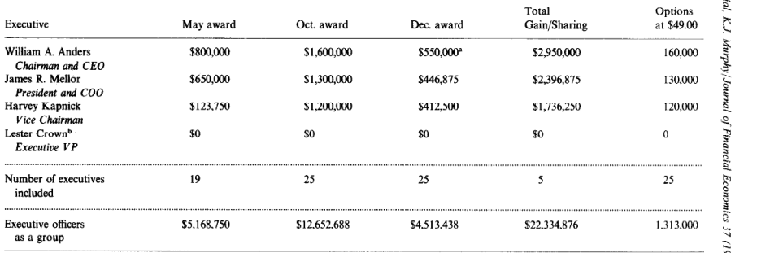

NOTE: complex table shown as an image of the PDF; the text below is a rough machine extraction and may be mis-aligned.

**extracted text (unreliable layout)**

Executive May award Oct. award Dec. award Gain/Sharing at $49.00

William A. Anders $800,000 $1600,000 rS550,000a S2,950,000 160,000

Chairman and CEO

James R. Mellor $650,000 %1,300,000 $446,875 %2,396,875 130,000

President and COO

Harvey Kapnick $123,750 %1,200,000 $412,500 $1,736,250 120,000

Vice Chairman

Lester Crownb $0 SO $0 $0 0

Executive VP

Number of executives 19 25 25 5 25 included

Executive officers $5,168,750 $12,652,688 $4,513,438 $22,334,876 1,3 13,000 as a group

-

Source: GD Special Meeting Proxy Statement, December 6, 1991.

“Since the increase at this time to $49 represented 34.375% of the $10 interval between $45.5625 and $55.5625, Anders’ received a final Gain/Sharing bonus

of $550,000 (or 34.375% of twice his $800,000 base sakrry).

bMr. Crown elected not to participate in the Gain/Sharing Plan,

Page 25

J. Dial, K.J. Murphy/Journal of Financial Economics 37 (1995) 261-314 285

The vehement public reaction to GD’s Gain/Sharing bonuses, coupled with the boards response to replace Gain/Sharing with conventional stock options, are evidence of the importance of political forces in shaping compensation policies (Jensen and Murphy, 1990). The GD experience is also consistent with the hypothesis that gains from options are politically more acceptable than gains paid in cash. In particular, criticism regarding GD’s compensation policies largely evaporated after GD replaced Gain/Sharing with conventional stock options, even though the payouts under the two plans were virtually identical (apart from the discontinuities imbedded in Gain/Sharing). Moreover, while Anders was heavily criticized for his Gain/Sharing bonuses of $2.95 million (accounting for approximately 0.3% of the total gain to shareholders), the $8.6 million appreciation of his restricted stock and options over the same time period escaped media attention. Similarly, the media focused on the $22.3 million Gain/Sharing payments to GD’s top management team, but ignored the $37 million appreciation the team realized on their options and restricted stock over the same ten months.25 The gains that top managers and the Crown family earned on their individual stockholdings also eluded notice, even though these gains were large relative to the Gain/Sharing payouts and were also associated with layoffs and downsizing.

3.7. Anders articulates and implements GD ‘s strategy

Although Anders had embraced the corporate objective of creating share- holder value upon his January 1991 appointment, the corporate strategy he developed to achieve this objective evolved during 1991 and 1992. An early indicator of the strategy- his pledge to not pursue diversification into non- defense businesses-was revealed at the September 1991 Morgan Stanley conference. Three weeks later, on October 16, GD announced that its largest nondefense subsidiary, Cessna Aircraft, was for sale. Later that month, in GD’s third-quarter report to shareholders, Anders announced that GD was studying all of its nondefense operations to determine if they should be separated from the company.

By the end of 1991, Anders was publicly urging the industry to both downsize and consolidate its businesses in order to ‘rationalize excess capacity’. He argued that only the top one or two contractors in a particular segment could survive the coming shake-out in defense. Anders stressed that no one should invest and grow in the defense industry (with the exception of a few market niches); only the strongest competitors should maintain investments; and that most should be

ZSCalculations based on options and current and promised restricted stock in Table 1 plus restricted stock held prior to February 1991, including 30,326 shares for Anders and 110,620 shares for all other top executives.

Page 26

286 J. Dial, K.J. MurphyJJournal of Financial Economics 37 (199s) 261.-314

managing for cash and taking money out of the defense segment. Some should simply exit the industry.26

In May 1992, Anders announced GD’s strategy within its defense businesses. Anders said GD would remain in businesses only where it could be # 1 or # 2 in the market, and only if it could achieve ‘critical mass’ with production large enough to justify dedicated factories. Anders announced that GD was prepared to buy businesses from, or sell businesses to, other parties in order to meet these ‘market leadership’ and ‘critical mass’ criteria. He identified four businesses within GD’s core defense capabilities that passed these two screens-military aircraft, nuclear submarines, land systems (tanks), and space systems-and announced a formal ‘plan of contraction’ in which the company would seek to sell units outside these four core defense businesses.

Anders discussed the rationale for this strategy and the reasoning behind the definition of the core segments:

When we assessed our businesses, we didn’t look at them in terms of core businesses, we looked at our core competencies. Our core competence is in heavy-weight defense platforms.

We also looked at efficiencies. The first test was whether we were or could be # 1 or # 2 in a market. The second test was whether each of these businesses could pass the criticaZ mass test. Could we justify dedicated factories for these products based on the scale we could achieve? The tank plant makes sense, subs make it, and tactical aircraft make it. Missiles did

not make it. They are not our core competence; they are a commodity business where supply far exceeds demand.

The difference between GD and the rest of the defense industry is that we wanted to sell nondefense businesses. And we were willing to fix any business by buying, selling, or merging. We were dedicated to shareholders and building franchises. Too many executives at other defense contractors are fixated on bigger is better. But, when the industry has excess capacity, the focus on continued growth just doesn’t work.

3.7.1. Sales of divisions and subsidiaries Table 3 summarizes GD’s sales of divisions between November 1991 and December 1993. GD sold the Data Systems Unit to Computer Sciences Corp. for $184 million, the Cessna Aircraft subsidiary to Textron for $600 million, its missile business to GM’s Hughes Electronics subsidiary for $450 million, its Electronics Division to Carlyle Group for $52 million, and the lime and brick operations of its Material Services businesses for $46 million.

*‘See, for example, William A. Anders, ‘Rationalizing America’s Defense Industry’, keynote address at the 12th annual Defense Week conference, October 30, 1991.

Page 27

J. Dial, K.J. Murphy/Journal of Financial Economics 37 (1995) 261-314 287

Table 3

General Dynamics divisions sold in 1991-1993

| Disposition |  |  | Sale price | 1991 revenues |
| --- | --- | --- | --- | --- |
| date | Division | Buyer | ($ millions) | ($ millions) |
| 1l/91 | Data Systems | csc | $184 | $12b |
| 2192 | Cessna | Textron | 600 | 797 |
| 8192 | Missiles | Hughes Aircraft | 450 | 1385 , |
| 11192 | Electronics | Carlyle Group | 52 | 218 |
| 3193 | Military Aircraft | Lockheed | 1525 , | 2719 , |
| 12/93 | Material Services’ | 0 | 46 | nia |
| 12193 | Space Systems | Martin Marietta | 209 | 363 |
| Total |  |  | $3066 , | $5494 , |

NOTE: table converted from PDF layout to HTML text; cell boundaries are reconstructed. See PDF if exact alignment matters.

Source: GD annual reports.

bFigure is for 1990.

‘Lime and brick operations only. 1991 revenues and buyer’s identity not available.

3.7.2. Employment Along with the sale of business units, GD continued to reduce its work force in its remaining units. As shown in Table 4, total employment at year-end 1993

“Jeff Cole, ‘Lockheed to Buy General Dynamics Fighter Plane Unit’, Wall Street Journal,

December 10, 1992.

*‘Jeff Cole, ‘Swords into Shares: General Dynamics Contemplates Selling Its Remaining Units’,

Wall Street Journal, November 3, 1992.

Page 28

288 J. Dial, K.J. Murphy/Journal of Financial Economics 37 (1995) 261-314

Table 4 General Dynamics work force reductions by business segment, 1991-1993

|  |  | Employment reductions | Units sold: | Units retained: |
| --- | --- | --- | --- | --- |
| Businesssegment | 1990 employment | through layoffs and attrition | Employment atdisposition | 1993 employment |
| Core defense Military aircraft Nuclear submarines | 28400 , 22500 , | 7200 , 5500 , | 21200 , | 0 17000 , |
| Tanks Spacesystems” | 7200 , 5200 , | 2200 , 1500 , | 3700 , | 5ooo , 0 |
|  | . |  |  | . |
| Total core defense | 63000 , | 16400 , | 24900 , | 22000 , |
| Noncore defense | 14300 , | 3000 , | 11300 , | 0 |
| Nondefenseb Corporate staff | 19900 , 650 | 7400 , 450 | 7900 , | 4600 , 200 |
| . . .. | . . | . . . |  | . |
| Total | 98150 , | 27250 , | 44100 , | 26800 , |

NOTE: table converted from PDF layout to HTML text; cell boundaries are reconstructed. See PDF if exact alignment matters.

Source: Annual reports and company estimates.

“Employees in the space- systems division are restated as leaving in 1993, although the sale to Martin

Marietta was not completed until April 1994.

‘Classified as discontinued operations.

stood at 26,800, a 73% reduction from the 98,150 employees at GD when Anders was appointed in 1991. The exhibit shows that 28% of GD’s 1990 workforce left through attrition or were laid off (most occurring in 1991), while 45% were active employees when their business units were sold (mostly in 1992 and 1993). The company has not estimated the number of employees laid off subsequent to these sales. The corporate headquarters staff fell from 650 to about 200. In order to reduce the overhead burden on the remaining businesses, the company announced plans to cut the corporate staff to just 50 by the end of 1994.

The company offered basic outplacement services for its discharged em- ployees, including counseling, help with resumes, and compiling and posting job opportunities. Most of GD’s discharged employees received three to six months salary upon dismissal (pursuant to labor agreements), and some corporate staff employees who had been recently relocated received additional compensation. Apart from offering limited computer tutoring at some locations, GD offered no formal training programs for its discharged employees.

3.7.3. Shareholders and shareholders ’ distributions As shown in Table 5, GD’s cash balance (before distributions) grew from $100 million in January 1991 to over $4 billion by the end of 1993. GD used its

Page 29

J. Dial, K.J. Murphy/Journal of Financial Economics 37 (1995) 261-314 289

Table 5 Simplified statement of sources and uses of cash for General Dynamics, 1991-1993

[output not shown]

NOTE: table converted from PDF layout to HTML text; cell boundaries are reconstructed. See PDF if exact alignment matters.

cash balance to:

l retire approximately 94% ($575 million) of the company’s debt, bringing GD’s total debt to just $38 million by December 1993;

l increase annual dividends from $1 per share to $1.60 in March 1992 and to $2.40 in October 1993; in March 1994, GD increased its annual dividend to $2.80 (prior to a 2: 1 stock split);

l repurchase over 13.2 million shares for $960 million (at an average of $72.75 per share) through a Dutch auction in June 1992;

l return $50 per share to shareholders in 1993 through special distributions in March ($20/share), June ($18/share), and October ($12/share).

By December 1993 the company had returned $3.4 billion to shareholders and debtholders, and had a remaining cash balance of nearly $600 million (approx- imately six times its cash balance in January 1, 1991). The composition of CD’s shareholders changed substantially in the summer of 1992. During the course of the Dutch auction in June, the Crown family tendered almost 4.9 million shares, reducing their stake in GD from 22% to 14.3%. Employees who held shares through GD’s SIP reduced their aggregate holdings from 14.7% to about 10% during the June auction. On July 24, investor Warren Buffett of Berkshire Hathaway announced the purchase of 4.35 million shares for about $73/share. He amassed a 15% stake in GD, thus surpassing the Crown family as GD’s largest shareholder. In a show of confidence in GD’s management, he gave the company his proxy to vote his shares ‘ . . . as long as Mr. Anders remains as chief executive officer of General Dynamics’.29

29’Business Brief: Warren Buffett Gives General Dynamics a Proxy to Vote Berkshire’s 15% stake’, Wall Street Journal, September 18, 1992. In May 1993, Buffet revised his grant of proxy to last ‘as long as Mr. Anders remains as chairman of General Dynamics’.

Page 30

290 J. Dial, K.J. Murphy/Journal of Financial Economics 37 (1995) 261-314

Daily stock prices from Dow Jones News Retrieval and Compustat. GD-related events from company press releases, analyst reports, and the Wall Street Journal. Industry and S&P 500 prices are determined by appreciating GD’s January 1, 1992 price by the cumulative returns on the industry and S&P 500 portfolios.

The remarkable success of GD’s strategy silenced many critics. For example, in October 1992, Prudential Bathe fired aerospace analyst (and GD critic) Paul Nisbet, citing poor stock-picking performance. In early 1991, Nisbet urged investors to sell their GD stock (priced at about $30), arguing that the stock was overvalued. After providing 22 ‘sell’ recommendations, N&bet went to a ‘hold recommendation in July 1992, after the price soared past $70 and Warren Buffet bought his 15% stake. 3o That same month, pay-critic Graef Crystal admitted in

3oJetT Cole, ‘Prudential’s Nisbet, Aerospace Analyst, Says He Was Fired’, Wall Street Journal, November 5, 1992.

Page 31

J. Dial, K.J. Murphy/Journal of Financial Economics 37 (1995) 261-314 291

Table 6 Distribution of value gain at General Dynamics, 1991-1993 ($ millions)

[output not shown]

NOTE: table converted from PDF layout to HTML text; cell boundaries are reconstructed. See PDF if exact alignment matters.

“GD Stock Investment Plan (SIP). Includes participation of managers and executives.

‘Stock for GD employees includes appreciation on restricted stock, on shares retained after exercising options, and on shares purchased through the SIP, but excludes appreciation on stock purchased by employees in private transactions.

dIncludes the $4,486 million gain to shareholders (including SIP participants) plus $22 million Gain/Sharing payments, $315 million payouts from options, and $41 in special distributions paid on restricted stock.

his monthly newsletter, ‘ . . . if we had spent less time criticizing [Anders’] pay package and more time increasing our investment in GD [shares], we would have been a lot better off financially’.31

Table 6 shows how the value gain was distributed among executives, em- ployees, and shareholders. Anders received $54 million through Gain/Sharing and appreciation on his restricted stock and options, representing about 1.1% of the total gain to shareholders. The other members of Anders’ top management team realized $258 million (approximately $11 million each, or 5.3% of the total gain), while 1,300 lower-level executives received $144 million (approximately $111,000 each). Employee participants in the SIP realized more than $450 million (approximately $10,000 per participant) over the 1991-1993 period, or

3’The Crystal Report on Executive Compensation, Vol. 4, No. 8, October 1992.

Page 32

292 J. Dial, K.J. Murphy/Journal of Financial Economics 37 (1995) 261-314

about 10% of the total gain. The Crown family-despite selling a large part of their GD stake-gained $743 million from their GD investment from 1991 to 1993, while Buffet’s stake-held for just 17 months-increased in value by $283 million.

3.8. Anders resigns as CEO

In March 1993, in addition to announcing its first special distribution, GD announced the resignation of three of its top executives-Chairman and CEO William A. Anders, Vice Chairman Harvey Kapnick, and Executive Vice President Lester Crown. ‘We have basically done the major part of the tur- naround job for which this team was assembled’, explained Anders.32 The three executives would remain on GD’s Board of Directors, and Anders would continue to serve as a nonemployee chairman of the board. James Mellor was named to succeed Anders as CEO. In March 1994, Anders resigned from the board, and Mellor assumed the additional role of chairman.

4. Strategies, incentives, and performance of other defense contractors

Having analyzed in detail GD’s strategy, incentives, and performance, we now briefly summarize the experience of other defense contractors subsequent to the end of the Cold War. This industry analysis is relevant to our study of GD for several reasons: First, supporting the hypothesis that GD’s actions were driven, in part, by its new management team and incentives, we establish that GD led, rather than followed, the industry in responding to anticipated cuts in defense expenditures. Second, we offer circumstantial evidence that Anders set the strategic objective for the industry: By 1993, most defense firms were adopting the strategy Anders outlined in industry speeches in late 1991 (see Section 3.7 above). Third, we show that Anders had significantly more stock-based financial incentives than the average firm in the industry or the S&P 500. Finally, we show that the industry’s ultimate consolidation, which was facilitated by GD, moved resources out of the industry and generated substantial shareholder wealth. The industry return from 1991-1993 (even excluding GD) more than doubled the return on the S&P 500, illustrating that opportunities to create wealth exist even in declining industries with few growth opportunities.

4.1. Strategic alternatives and choices of other contractors

Table 7 summarizes the strategies selected by GD and eight other defense contractors from 1990 through 1993, based on an analysis of quantitative

32Jeff Cole, ‘Three Officers to Quit General Dynamics Corp.: End of Turnaround Plan Brings a Cash Payout, Cuts at Headquarters’, Wall Street Journal, March 19, 1993.

Page 33

financial data as well as our qualitative interpretation of annual reports, press releases, and news articles. The table includes nine of the eleven largest domestic defense contractors (ranked by cumulative 1989-1992 defense contracts) - miss- ing are General Electric and Boeing because their defense operations account for less than 10% of total firm revenues. Some of the strategic options adopted by these firms include: Acquisitions to achieve critical mass; diversification into nondefense areas or converting defense operations to commercial products and services; globalization, i.e., finding international markets for defense operations; downsizing and consolidation; and exit (Lundquist, 1992; Minnich, 1993).

Acquisitions to achieve critical mass. Five of the eight defense contractors in Table 7 adopted Anders’ critical mass criteria, and sought to achieve critical mass in production through acquisitions. GM Hughes acquired GD’s missile division for $450 million in 1992, and Lockheed acquired GD’s aircraft division for $1.5 billion in 1993. Martin Marietta acquired GE Aerospace for $3 billion in 1992 and GD’s Space Systems for $209 million in 1994. Northrop purchased LTV’s aircraft division for $225 million in 1992, and won a bidding war with Martin Marietta to acquire Grumman for $2.17 billion in 1994. Although not included in Table 7, Loral acquired Ford Aerospace for $715 million in 1990, LTV’s missile business for $240 million in 1992, and IBM’s Federal Systems division for $1.5 billion in 1994. Also in 1994, Lockheed and Martin Marietta agreed to a merger via a stock swap that created the U.S.’ largest defense contractor and led to further consolidation in the industry. By merging, acquiring, and consolidating businesses, these defense contractors have lowered overhead costs and avoided duplication of research and development expenses (Lundquist, 1992). In addition, these acquisitions, financed largely with cash, have created value by transferring over $10 billion from the industry to target-firm share- holders who can reinvest in more productive sectors (Jensen, 1983).

Diversijication and commercialization. A 1992 survey of 148 defense companies sponsored by a defense/aerospace consulting firm found that more than half of the respondents report past attempts to ‘commercialize’ (i.e., applying defense technologies to commercial products) and more than three-quarters predict future commercialization.33 For example, Hughes is applying its satellite tech- nology in a commercial venture called satellite direct TV, designed to compete directly with cable television. Lockheed is pursuing commercial satellite and satellite launch customers, and is converting its defense systems businesses into systems for collecting child support payments and traffic tickets, and bar coding applications for the postal service. Other firms are adopting more traditional

33Rick War&man, ‘Peace Initiative: Lockheed Navigates the Tricky Transition to More Civilian

Work’, Wall Street Journal, February 10, 1992.

Page 34

Table 7

Summary of defense revenues, strategy, capital expenditures, and employment of major defense contractors

Company

GM Hughes

Grumman

Lockheed

Martin

Marietta

McDonnell

Douglas

Dept. of Defense

prime contracts=

($ billions)

1989- As % of

1992 total rev.

$12.3 26.1%

$9.6 64.3%

$14.5 36.5%

$11.9 49.6%

$30.2 45.3%

[output not shown]

NOTE: table converted from PDF layout to HTML text; cell boundaries are reconstructed. See PDF if exact alignment matters.

% change

Strategyb 1989 1990 1991 1992 1990 1991 1992 1990-92

conversion, downsizing, exit

Critical mass, downsizing, exit 56.0% 48.4% 59.1% 49.2% 26,100 23,600 21,200 - 18.8%

Critical mass, conversion, 109.4% 93.4% 93.7% 93.1% 73,000 72,300 71,700 - 1.8%

globalization, downsizing

Critical mass, diversification, 127.6% 114.8% 88.8% 72.9% 32,900 32,000 e N/A

globalization, downsizing

Critical mass, globalization, 112.2% 10.0% 31.9% 63.5% 121,190 109,123 87,377 - 27.9%

conversion, downsizing, exit

Page 35

[output not shown]

NOTE: table converted from PDF layout to HTML text; cell boundaries are reconstructed. See PDF if exact alignment matters.

Northrop

Raytheon $14.8 40.6% Conversion, globalization, 135.0% 117.1% 84.7% 71.3% -e c .~ e N/A

downsizing

United $12.0 14.4% Globalization, downsizing 131.9% 136.4% 128.3% 100.7% 45,700 44,400 41,000 - 10.3%

Technologies

. . . . . .

General

Dynamics $25.5 76.3% Downsizing, exit 108.8% 84.9% 17.9% 16.3% 98,150 80,600 35,650 - 63.7%

“Department of Defense, ‘100 Companies Receiving the Largest Dollar Volume of Prime Contract Awards’, various issues (excludes sales to foreign countries,

thus defense business is understated in terms of total revenue and as a percentage of firm revenue); firm revenues from company annual reports.

“Subjectively determined from a variety of sources, including analysts reports, trade publications, business press, and company reports.

‘Data from annual reports and Aircraft Owners and Pilots Association Industry Sector Analysis Data Base, provided to us by General Dynamics.

‘Figures reported by Aerospace Industries Association.

‘Segment data not available.

‘Excludes Martin Marietta and Raytheon from summary total.

Page 36

diversification strategies: Raytheon, for example, diversified into corporate jets by acquiring British Aerospace’s business-jet unit. Martin Marietta CEO Norman Augustine, however, cautioned his industry counterparts about wan- dering too far from their areas of expertise:

Our industry’s record at defense conversion is unblemished by success. Why is it rocket scientists can’t sell toothpaste? Because we don’t know the market, or how to research, or how to market the product. Other than that, we’re in good shape.34

Globalization. A number of firms are retaining a defense focus, attempting to bolster sales through globalization, selling U.S. built weapons abroad. This strategy is unlikely to yield dramatic growth, since the demand for weapons is declining world-wide and many foreign countries have their own national producers who are also faced with excess capacity (Lundquist, 1992). Neverthe- less, augmenting domestic sales with foreign contracts can help to build critical mass in businesses with waning support from the U.S. government. Raytheon, one of the few defense contractors that is successfully pursuing a globalization strategy, hopes to achieve 40% of military sales outside of the U.S., principally on sales of its Patriot missile in the Mideast.

Downsizing, consolidation, and exit. Table 7 shows that while most contractors adopted a combination of strategies, all adopted some form of downsizing or consolidation to reduce excess capacity. However, while a few contractors (including GM Hughes, Grumman, and McDonnell Douglas) have divested unprofitable noncore businesses where they had little chance of building stra- tegically competitive positions, only General Electric (not included in Table 7) followed GD in exiting key segments of the defense industry. Interestingly, it was General Electric (where Anders held his first general management position) that pioneered the ‘# 1 or # 2’ criterion as a strategic assessment for the composition of its portfolio of business units. Table 7 reports the ratio of capital expenditures to depreciation within the defense segments of major defense contractors from 1989 through 1992. Ratios exceeding 100% indicate that firms are investing more than is required to replace depreciating assets, while ratios less than 100% indicate that firms are not fully replacing depreciating assets. The table shows that a composite (weighted average) ratio among eight key contractors fell from 108% in 1989 to just 79% in 1992. However, the table shows that GD cut its capital spending faster and deeper than other defense contractors: GD’s ratio of capital expendi-

tures to depreciation approximated the industry average in 1989 and 1990, but

34‘Still Waiting for the Bang’, The Economist, October 2, 1993.

Page 37

J. Dial, K.J. Murphy/Journal of Financial Economics 37 (1995) 261-314 297

plummeted to just 17.9% and 16.3% in 1991 and 1992, respectively. Table 7 also shows that total employment within the defense/aerospace segments of these same contractors fell by 13.6% from 1990 to 1992. Meanwhile, GD reduced its employment by 63.7% over the same period through layoffs, sell offs, and attrition (see also Table 4). Goyal, Lehn, and Racic (1993) also analyze investment policies in the defense industry. They report evidence that defense contractors began transferring resources from the industry as early as 1989-90 through increased leverage, dividends, and share repurchases. Our complementary evidence suggests that although other contractors also espoused and eventually adopted consolidation and downsizing, GD’s response in moving resources out of the industry was quicker and more dramatic. To draw an analogy: While other defense con- tractors engaged in a high-stakes game of musical chairs- hoping to be seated when the music stopped-GD pursued a strategy of offering its chair to the highest bidder.

4.2. Incentives and performance in the defense industry

Table 8 compares Anders’ stock-based incentives to those of CEOs in other major defense contractors and in the S&P 500, using data from corporate proxy statements covering the 1992 fiscal year. 35 Financial incentives to create value come predominantly from stock options, restricted stock, and stock ownership (Jensen and Murphy, 1990; Murphy, 1993). Cash compensation plans explicitly based on stock prices-such as GD’s Gain/Sharing Plan which was ultimately converted to stock options -are unusual. Therefore, we focus on these three components of incentives and ignore incentives associated with salaries, bonuses, and other cash plans. We define ‘incentives’ as the fraction of the shareholder gain ‘paid’ to the CEO through appreciation of his stock and option holdings. Table 8 shows that Anders held stock options on 1.39% of GD’s outstanding shares (including the options granted when Gain/Sharing was discontinued), substantially more than the average holdings in the industry (0.29%) or the S&P 500 (0.20%). In addition, Anders held restricted stock on 0.32% of GD’s shares, compared to industry and market averages of 0.05% and 0.03%, respectively. Together-assuming the options are sufficiently in-the-money- these two com- ponents imply that Anders’ receives approximately 1.7% of the gains to GD shareholders, between five and seven times the average percentage in the industry (0.34%) and market (0.23%), respectively. [Anders’ estimated incen- tives of 1.7% are higher than the 1.1% reported in Table 6 because Anders exercised and sold 150,000 shares in December 1992. The 1.7% represents his marginal incentives at the end of 1992 (prior to the exercise) rather than the

35Pro~y data were unavailable for 74 S&P 500 companies.

Page 38

[output not shown]

NOTE: table converted from PDF layout to HTML text; cell boundaries are reconstructed. See PDF if exact alignment matters.

Table 8

Stock-based incentives and shareholder returns in the defense industry and the S&P 500

Percentage of outstanding shares held by CEO, Rate of return realized by shareholders (dividends

fiscal 1992 reinvested)

Stock Restricted Stock 1987- 1991p

Company options stock owned Total 1990 1991 1992 1993 1993

GM Hughes” 0.00% 0.00% 0.02% 0.02% 0% - 13% 80% 55% 143%

Grumman 0.24 0.06 0.12 0.42 -2 -5 47 66 131

Lockheed 0.33 0.00 0.02 0.35 - 21 40 31 25 130

Martin Marietta 0.35 0.05 0.02 0.42 27 39 20 31 118

McDonnell Douglas 0.00 0.00 3.34 3.34 - 35 93 - 32 126 197

Northrop 1.05 0.04 0.68 1.77 -46 59 36 14 147

Raytheon 0.08 0.12 0.03 0.23 18 22 27 31 103

United Technologies 0.48 0.05 0.05 0.63 20 18 -8 33 44

. . . . . . . . . . . . . . . . . . . . . . . . . . . . . . . .

Industry average 0.29% 0.05% 0.31% 0.61% 11% 29% 16% 41% 110%

General Dynami& 1.39% 0.32% 0.05% 1.76% - 59% 118% 97% 48% 537%

S&P 500 0.20% 0.03% 0.75% 0.98% 56% 30% 8% 10% 55%

Industry and S&P 500 averages are value-weighted. Weights for industry performance are 1 l/91 market capitalizations. Data on stock-based incentives

from fiscal 1992 proxy statements; proxy data were available for 426 of the S&P 500 companies.

“Incentive data reflects GM’s CEO’s holdings of GM Hughes stock; ownership data for the head of GM’s Hughes subsidiary are not available.

‘Anders’ stock-based incentives are calculated before his December 1992 option exercise. They reflect 431,359 stock options, 15,500 purchased shares, and

100,700 restricted shares (including 30,940 shares granted in lieu of benefits he would have received at Textron; these shares were held in a GD deferred

account until late 1992, when Anders received the value of the shares in cash). Anders’ incentives from Gain/Sharing discontinued in December

1991~ are not included, but the incentives from the options that replaced Gain/Sharing are included.

Page 39

J. Dial, K.J. Murphy/Journal of Financial Economics 37 (1995) 261-314 299

‘average’ incentives over the 1991-1993 period.] As a new CEO, Anders held substantially less stock than the average CEO in the industry and market; these shares provide incentives even though they are not controlled by the compensa- tion committee. Anders’ overall incentives (including stock owned) are about three times the average incentives for CEOs in the industry and twice the average incentives for CEOs in the market.

We also compared the 1992 incentives for defense-firm CEOs to incentives four years earlier, based on 1989 proxy statements. Incentives for GD’s CEO (Anders in 1992, Stanley Pace in 1988) increased 1.47% from 0.29% to 1.76%. In contrast, the change in incentives in the other eight firms ranged from - 1.07%

to 0.29%, with a median change of 0.1%. Although the estimates of 1988 and 1992 incentives are not strictly comparable due to changes in CEOs and reporting requirements, our results suggest that, measured relative to changes in other defense firms, CEO incentives at GD increased substantially from 1988 to 1992.36

GD contributed to the 1993 wealth creation among other defense firms by facilitating a consolidation of the industry and leading the wave of defense- related layoffs and acquisitions that had returned over $10 billion to share- holders by early 1994. Focusing on core businesses, shedding underperforming assets, closing facilities, consolidating divisions, reducing debt, and cutting

361n particular, firms did not disclose outstanding stock options in 1988. We estimate 1988

outstanding options as the sum of 1988 grants and options exercisable within 60 days. In addition,

firms did not uniformly report restricted shareholdings in 1988.

Page 40

capital expenditures and employment has substantially strengthened the com- petitive position of many contractors as they have reduced both financial and operating leverage.

5. Sources of GD’s value gain

Table 9 decomposes the sources of GD’s $4.486 billion value gain from 1991-1993. It estimates the fraction of the value gain that plausibly reflects GD’s new management team and incentives, and the fraction that is best explained by market and industry stock-price movements and by events affecting GD’s stock price that are unrelated to the implementation of GD’s strategy. The estimates in the table are based on the S&P 500 Index, performance of the industry in excess of the S&P 500, and the industry-adjusted three-day announcement returns of events affecting GD’s stock price (as reported in Appendix B). Each event in Appendix B includes a designation of exogenous, earnings, distributions, downsizing, or strategy. Exogenous events-such as the Gulf War, the Soviet Coup, awards (or cancellations) of CD contracts-are events not plausibly driven by GD’s new management team and incentives. Earnings includes earnings announcements. Distributions includes events related to divi- dends, share repurchases, and special distributions (including ex-divided dates). Downsizing includes announcements related to layoffs and sales of divisions. The final category, Strategy, includes events related to Gain/Sharing, Anders’ speeches, analyst reports, and other announcements directly related to GD’s strategy. We consider that events related to earnings, distributions, downsizing, and strategy plausibly reflect GD’s new management team and incentives. Table 9 shows that $956 million of GD’s gain (21% of the total) can be explained by general market movements, while $1.076 billion (24% of the total) can be explained by industry-specific movements. Exogenous events not directly linked to Anders’ strategy account for $21 million, bringing the total gain ex- plained by market, industry, and exogenous factors to $2.053 billion, or about 46% of the total gain to shareholders. Announcement returns related to earnings, distributions, downsizing, and strategy account for $2.322 billion (or 52% of the total). Together, the market and industry adjustments and the announcement returns explain 98% (all but $111 million) of the total gain to GD shareholders. The $2.3 billion estimate of value gain explained by Anders’ strategy excludes the $111 million ‘unexplained’ component and the $1.1 billion explained by industry-specific movements (in excess of the market). In estimating the fraction of GD’s value gain plausibly driven by its management team and incentive structure, it seems appropriate to exclude exogenous factors affecting the entire industry. For example, if the 41% industry return in 1993 (see Table 8) reflected increased demand for new weapons systems, it would be inappropriate to attribute that demand shift to actions taken by GD’s managers. However, the

Page 41

J. Dial, K.J. Murphy/Journal of Financial Economics 37 (1995) 261-314 301

Table 9 Sources of value gain at General Dynamics, 1991-1993 ($ millions)

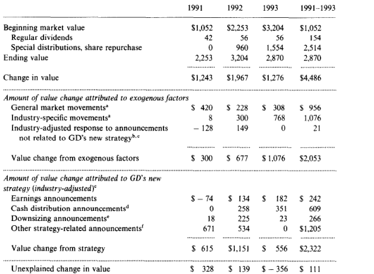

NOTE: complex table shown as an image of the PDF; the text below is a rough machine extraction and may be mis-aligned.

**extracted text (unreliable layout)**

“General market movements am calculated daily as V - r , r ,,,L, where V, - 1 is GD’s market value on day t - 1, and r,, is the return on the S&P 500 index on day t. Industry-specific movements are calculated daily as V,- i(r,, - r,), where 4, is the value-weighted return on the eight defense firms in Tables 7 and 8.

“Includes announcements of defense contracts, world events (such as the Gulf War and the Soviet Coup), and other announcements as designated in Appendix B.

“Industry-adjusted responses (as reported in A * ppendix B) are calculated as V, _ *(R1 - Ri,), where

R, and Ri, are the three-day returns surrounding each announcement for GD and the industry, respectively, and V,-, is GD’s market value two days prior to the announcement.

%cludes announcements related to dividends, share repurchases, and special distributions (including ex-dividend dates) as designated in Appendix B.

‘Includes announcements related to layoffs and sales of divisions as designated in Appendix B.

‘Includes responses to Gain/Sharing, Anders’ speeches, analyst reports, and other announcements designated in Appendix B.

stellar performance of the defense industry in 1992-1993 was not driven by an increase in weapons contracts, but by explicit managerial responses to declining demand, including mergers, consolidations, and downsizing. GD was an active player, not an innocent bystander, in this process, and both GD’s and the

Page 42

302 J. Dial, K.J. Murphy/Journal of Financial Economics 37 (1995) 261-314

industry’s returns would plausibly have been lower without Anders’ active participation. Therefore, depending on how the industry and unexplained com- ponents are interpreted, our estimates of the value gain attributable to GD’s management and incentive structure range from $2.3 billion to $3.5 billion. The evidence presented in this paper, including Table 9, support the hypotheses that GD’s remarkable shareholder performance was driven in large part by its top management team and its incentive structure. In the remainder of this section, we address three questions related to the sources and disposition of the value gain. First, was the value gain simply a transfer of wealth from (former) GD employees to shareholders? Second, rather than returning cash to share- holders, should GD have used its excess cash to diversify or to retain workers?

Finally, could GD’s results have been achieved with fewer executive incentives?

5.1. Did the value gain at General Dynamics come at the expense of GD workers?

GD, with a January 1991 market capitalization of $1 billion and less than $1 billion in long-term debt, generated almost $4.5 billion in wealth for share- holders in less than three years. The underlying theme in this study is that value was created as resources used in defense were diverted to more highly valued uses. The fact that the diversion was associated with large increases in stock prices suggests that the stock market expected that efficient resource allocation was unlikely. The fact that GD had a 1991 market value (including debt) of less than $2 billion while having over $10 billion in revenues, a $23 billion backlog, over $6 billion in assets, 98,000 employees, and annual capital and R&D spending in excess of $700 million, is further evidence that the market expected GD to e z mploy its resources inefficiently.

Fig. 1 suggests that the market began anticipating cuts in future defense spending as early as 1987: GD’s shareholders realized a 59% loss from January

1987 through December 1990. Moreover, the industry (excluding GD but including the other firms in Table 8) managed a meager cumulative 11% return over the same four years, far less than the 56% return on the S&P 500 from

1987-1990. The market evidently discounted the probability that the defense industry would respond efficiently to the changing defense market.

The increase in GD’s value reflects, in part, the gain to society from diverting capital resources to more highly valued uses (e.g., GD’s drastic cuts in capital expenditures). In addition, part of the increase in GD’s value reflects the gain from diverting human resources to more highly valued uses, and part reflects a wealth transfer from employees to shareholders. Employees are worse off by the differences between their wages at GD and the wages in their next-best alterna-

tives; however, society is better off by the differences in the employees’ value at their next-best alternative and their value as defense workers at GD. To the extent that employees could earn a similar wage in the nondefense sector, the increase in GD’s value represents a dollar-for-dollar increase in societal wealth. To the

Page 43

J. Dial, K.J. Murphy/Journal of Financial Economics 37 (199.5) 261-314 303

extent that employees must accept much lower wages, the relevant issue is why they had originally been paid a premium to work in the competitive defense industry. Presumably, this premium reflected the specialized skills required for the industry, and also reflected a compensating differential for risky employment in an industry with historically variable demand. In addition, the premium reflects the wealth transfer from taxpayers to employees that occurred when defense contractors passed high labor costs directly to taxpayers under contracts awarded on a cost-plus basis. By shifting to fixed-price contracts in the late 1980s Congress shifted the burden of overpaid employees from taxpayers to shareholders. The elimination of the subsidized overpayment to defense employees will harm affec- ted employees, but generally benefit shareholders and society.

We have not attempted to separate quantitatively the portions of the increase in GD’s shareholder wealth that reflect societal gains versus transfers from employees. It is worth stressing, however, that the fact that some of the gain reflects transfers does not imply that shareholders were expropriating wealth from defense workers who had ‘rights’ to perpetual wage premiums. There is no evidence that GD had an implicit or explicit contractual obligation to continue paying rents to employees following the end of the Cold War. There is evidence, however, that the market expected the company to waste resources by paying workers high rents to continue producing products that society no longer valued.

5.2. Should General Dynamics have used its excess cash to diver@ or retain workers?

Although politicians, journalists, and labor leaders argued that GD should have retrained their defense-specific employees, Anders believed that retraining programs would be an inappropriate use of shareholder money:

I do not see that we have a special obligation to our employees. This is an issue of excess human capacity that had to leave the defense industry. We

trained our people to have specific skills and paid for that training. Then we paid them for their skills. What are we to do when those skills are no longer required? We have a lot of very skilled welders at Electric Boat that earn about twice what they can earn on the outside where that level of skill is not required. We are not going to start to build bridges. That’s not our business and not our obligation. The loss of jobs at GD is actually better for America if we redeploy those

assets appropriately. We have done more than any other defense contractor in creating new jobs by putting $3.4 billion back into investments - by letting shareholders redeploy those resources in new industries for new products.

Page 44

304 J. Dial, K.J. Murphy/Journal of Financial Economics 37 (1995) 261-314

Academic proponents of company-sponsored retraining programs argue that such programs are part of the optimal implicit contract between employees and employers. It is difficult to disprove the existence of implicit contracts, since these contracts by definition are not written, but exist only in the minds of the employees and the employer. We argue, however, that rational employees would not expect a firm to honor this type of implicit contract in the event the firm downsizes or exits particular business lines. Implicit contracts are enforced through reputational concerns: Reneging on contracts with current workers makes it more costly to enter into similar contracts in the future. However, when the likelihood of future contracting is substantially reduced (or nonexistent in the case of a full liquidation), enforcing the implicit contract becomes more difficult. Consequently, implicit promises by a firm to provide retraining coinci- dental to downsizing or liquidation are not credible. Employees who desire this type of employment insurance would not likely rely on implicit contracts, but would instead demand explicit contracts specifying employment guarantees, severance payments, and retraining programs in the event of liquidation. Al- though GD did write (and honor) explicit contracts with some union workers and top managers, these contracts did not include retraining provisions. The relevant question is not whether defense workers should be retrained, but who should provide the retraining. Retraining will have to occur, since the specific skills required in the defense industry are not readily transferable to other industries. The worker has the best information to determine how to retain, and to choose the industrial sectors promising the best alternative employment oppor- tunities. In contrast, the company has neither the information nor the expertise to be an efficient provider of retraining for unemployed defense workers.

5.3. Could General Dynamics ’ results have been achieved with fewer executive incentives?

One of the more important issues raised by the GD case is whether the strategy it ultimately adopted could have been developed and implemented without the large ex post rewards to top managers. Anders, after all, was already paid an annual salary of $800,000 to act in the interest of GD shareholders. Why did he need additional incentives to do what he was hired to do? The strategies adopted by GD - including downsizing, restructuring, liquida- tion, and returning excess cash to shareholders-seem obvious, given the projected reductions in defense budgets associated with the end of the Cold War. However, despite ample evidence of a changing defense market available to all defense contractors, only GD followed the ‘obvious’ strategy. While other contractors reduced their work forces to some degree, no one took the drastic actions that GD did in 1991 and 1992 to reduce capital expenditures and employment, and no other firm elected to convert their assets to cash and return financial resources to shareholders.

Page 45

J. Dial, K.J. Murphy/Journal of Financial Economics 37 (1995) 261-314 305

The new management team and new incentive programs were introduced simultaneously. It is therefore difficult to identify the relative importance of incentives versus the particular individuals in the team. It is worth noting, however, that Anders and the other top executives believe that the Gain/Sharing Plan and other plans linked to value creation were crucial elements of GD’s ultimate success. Anders stresses the importance of creating the ‘partnership mentality’ among top managers, who began to think like owners rather than hired hands. The decisions GD managers made were not easy, and the incentives had to be strong enough to attract and retain the right executives, ensure timely and comprehensive disclosure of critical information, and motivate the right decisions. Ultimately, the incentives had to be strong enough to make the executives willing to sacrifice their own jobs and positions. Several top GD executives (including Anders) have left the company, and many of those remain- ing (including new CEO Mellor) have accepted substantial pay reductions to reflect the reduced complexity of the smaller corporation they now manage. Such voluntary turnover and pay cuts are unusual in U.S. corporations. The argument that high-salaried managers should take actions that benefit shareholders-even without high-powered incentives-is at odds with the evid- ence in a growing number of corporate giants, including IBM, General Motors, Kodak, Westinghouse, and Sears. In these firms, as well as many others, creating value for shareholders means downsizing and moving human and physical capital out of the industry. Managers in these firms resisted major changes until the changes were forced upon them by market pressure; IBM, for example, brought in a new manager to make meaningful changes only after shareholders lost over $50 billion in less than two years.

6. Conclusion

Jensen (1993) argues that rapid increases in technology, declines in regulation, growing worldwide capitalism, and globalization of trade have created massive excess capacity in many of the world’s industries. GD’s response to excess capacity in the defense industry has important implications for many firms across a wide range of industries facing similar economic pressures.

First, the GD case suggests the importance of stock-based compensation in firms characterized by excess capacity: GD downplayed accounting-based bonuses and focused on stock options, restricted stock, and other compensation plans tied to value creation. Second, GD’s experience illustrates the large political costs associated with success when success mean downsizing and layoffs, and also suggests that these costs can be mitigated by avoiding cash payments, relying instead on gains through ownership. Third, appropriate incentives must be coupled with the appropriate managers: Anders believes that his strategy could not have been implemented without the incentives, but the

Page 46

306 J. Dial, K.J. Murphy/Journal of Financial Economics 37 (1995) 261-314

case facts also suggest that Anders’ actions transcended his individual incentives. Finally, although declining industries with excess capacity offer relatively few opportunities for revenue growth, the GD case suggests that these industries may offer large potential opportunities for value creation. Even though GD’s situation is replicated in many firms and industries, its response and ultimate achievements are remarkable. Excess capacity necessi- tates downsizing and transferring resources to higher-valued uses. However, few managers have been able to accomplish the necessary resource redirection until their organizations faced crises in the product, factor, or capital markets. GD’s board and top management team were remarkably consistent in pursuing their objective of creating shareholder wealth in spite of enormous pressures from employees, unions, the media, and the government to do otherwise. Overall, GD

stands out as the preeminent shareholder success story of the early 1990s and may serve as a blueprint for compensation and strategy decisions in other industries with excess capacity.

Appendix A

General Dynamics board of directors and stock ownership, February 15, 1991

| Director | Restricted and unrestricted sharesheld | Stock options heldb |
| --- | --- | --- |
| CURRENT MANAGEMENT |  |  |
| William A Anders (age57 director since 1990) . , | 106586’ , | 271359 , |
| Chairman and CEO Lester Crown (age65 director since 1974) , | d - | 60412 , |
| Executive Vice President |  |  |
| Chairman of Material Service subsidiary JamesR Mellor (age60 director since 1981) . , | 76469 , | 133613 , |
| President and Chief Operating Officer Russell W Meyer Jr (age58 director since 1986) . , . , | 15071 , | 0 |
| Executive Vice President of the Corporation |  |  |
| Chairman of Cessna Aircraft subsidiary Herbert F Rogers (age65 director since 1987) . , | 44323 , | 22157 , |
| Vice Chairman of the Corporation |  |  |
| FORMER MANAGEMENT |  |  |
| David S Lewis (age73 director since 1970) . , | 53450 , | 0 |
| Former Chairman and CEO StanleyC Pace(age 70 director since1985) . , | 47701 , | 22190 , |
| Former Chairman and CEO |  |  |

NOTE: table converted from PDF layout to HTML text; cell boundaries are reconstructed. See PDF if exact alignment matters.

Page 47

J. Dial, K.J. h4urphy/Journal of Financial Economics 37 (1995) 261-314 307

|  |  | Restricted and | Stock |
| --- | --- | --- | --- |
|  |  | unrestricted | options |
| Director |  | shares held” | held” |
| CROWN FAMILY |  |  | - |
| James S Crown (age 37 director since 1987) . , |  |  |  |
| General Partner Henry Crown and Company , |  |  |  |
| Charles H Goodman (age 57 director since 199kl) . , | i | 9187149’ . , | 0 |
| Vice President Henry Crown and Company , |  |  |  |
| Vice President CC Industries Inc , , . |  |  |  |
| NONMANAGEMENT |  |  |  |
| Thomas G Ayers (age 76 director since 1980)’ . , |  | 300 | 0 |
| Former Chairman and CEO of Commonwealth Edison |  |  |  |
| Frank C Carlucci (age 60 director since 1991) . , |  | 1050 , | 0 |
| Vice Chairman The Carlyle Group , |  |  |  |
| Former Secretary of Defense |  |  |  |
| Harvey Kapnick (age 65 director since 1980)’ , |  | 500 | 0 |
| President Kapnick Investment Co , . |  |  |  |
| Alien E Puckett (age 71 director since 1987)’ . , |  | 1000 , | 0 |
| Chairman Emeritus of Hughes Aircraft Company |  |  |  |
| Bernard W Rogers (age 69 director since 1987) . , |  | 300 | 0 |
| Retired General former Chief of Staff , |  |  |  |
| Former Supreme Allied Commander Europe US Army , . . |  |  |  |
| Elliot H Stein (age 72 director since 1978)’ . , |  | 2500 . | 0 |
| Chairman Emeritus of Stiefel Financial Corporation |  |  |  |
| Cyrus R Vance (age 74 director since 1987) . , |  | 300 | 0 |
| Chairman Federal Reserve Bank of New York , |  |  |  |
| Former Secretary of State |  |  |  |

NOTE: table converted from PDF layout to HTML text; cell boundaries are reconstructed. See PDF if exact alignment matters.

Source: GD 1991 Proxy Statement, March 28, 1991. There were 41,870,868 shares outstanding on

2/15/91.

“Includes restricted shares granted or promised on (or before) February 15, 1991.

“Includes options granted (and exchanged) on February 15; all options listed have an exercise price

of $25.5625 per share.

‘Anders shares include 500 shares purchased before 1991,10,000 shares purchasedin February 1991,

30,326 shares of restricted stock granted in lieu of benefits he would have received at Textron (held in

a deferred account), and 65,760 restricted shares granted or promised in February 1991.

%ee Crown family holdings below.

‘Includes Lester Crown’s 24,310 restricted shares. Many of the shares owned by Lester Crown,

James S. Crown, and Charles Goodman are jointly owned through Crown family trusts. The total

ownership by the Crown family amounts to approximately 22% of General Dynamics common

stock.

‘Member of compensation committee.

Page 48

Appendix B

Stock market reactions and shareholder value changes in response to announcements and events for General Dynamics, aerospace/defense industry, and the S&P

500, 1991-1994

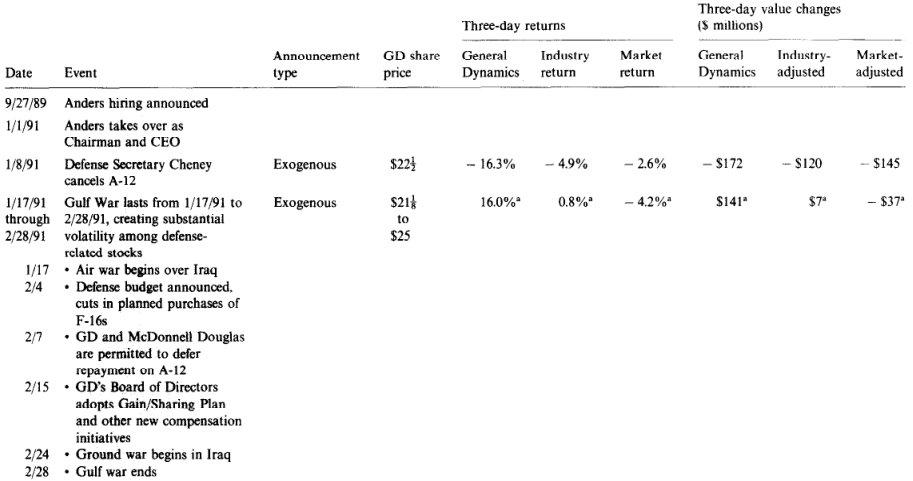

NOTE: complex table shown as an image of the PDF; the text below is a rough machine extraction and may be mis-aligned.

**extracted text (unreliable layout)**

Date

9127189

l/1/91

l/8/91

l/17/91

through

2128191

l/17

214

217

2115

2124 l Ground war begins in Iraq

2128 - Gulf war ends

Announcement

type

adjusted Market-

adjusted

Anders hiring announced

Anders takes over as

Chairman and CEO

Defense Secretary Cheney

cancels A-12

Gulf War lasts from l/17/91 to

2/28/91, creating substantial volatility among defense-

related stocks

l Air war begins over Iraq

l Defense budget announced,

cuts in planned purchases of

F-165

l GD and McDonnell Douglas

are permitted to defer

repayment on A-12

l GD’s Board of Directors

adopts Gain/Sharing Plan

and other new compensation

initiatives

Exogenous

Exogenous

- $120 - $145

$7” - $37”

Page 49

3,‘20/9 1

312819 1

41319 1

4117191

4/23/9 1

5/l/91

51619 1

s/9/9 1

7117191

Goldman Sachs, Morgan

Stanley, and Paine Webber

recommend GD stock, citing

managerial incentives and

changes underway

GD lays off 2,000 at jet plant

South Korea cancels purchase

of McDonnell Douglas

fighters and surprises

observers in announcing

$5.2 billion purchase of

F-16s

ECgypt buys 46 more F-16s

First quarter earnings down

56% (excluding 1990 onetime gain, earnings down

21%)

Lockheed/GD/Boeing team wins

ATF award

Shareholders ratify Gain/

Sharing Plan, Mellor says

GD to cut 30,000 jobs by

1994

Navy awards Seawolf nuclear

sub to GD, first Gain/Sharing

payoff

Judge halts Seawolf award

Second quarter earnings

($211 M), up from $240 M

loss in 1990

[output not shown]

NOTE: table converted from PDF layout to HTML text; cell boundaries are reconstructed. See PDF if exact alignment matters.

Exogenous

Earnings

Exogenous

Strategy

Exogenous

Strategy

Exogenous

Earnings

$7

Page 50

[output not shown]

NOTE: table converted from PDF layout to HTML text; cell boundaries are reconstructed. See PDF if exact alignment matters.

Date Event Announcement

a/19/91

through

8/21/91

9 12419 1

10/8/91

10/17/91

10/21/91

1012919 1

l/9/92

l/21/92

213192

GD gets contract to build tanks

for Army

Soviet Coup lasts from g/19/91

to B/21/91

Anders addresses defense analyst

conference, GD sells data unit

to CSC for S184 M (9/22),

more Wall Street firms say ‘Buy’

Second Gain/Sharing payoff

GD announces plan to divest

Cessna

Third-quarter earnings ($71 M)

up 4%

Anders speech outlines strategic

options

U.S. seeks to settle suit over

A-12

GD announces sale of Cessna

to Textron

Fourth-quarter earnings

($166 M), up from $530 M

loss in 1990

Exogenous

Exogenous

Strategy

Downsizing

Strategy

Downsizing

Earnings

Strategy

Exogenous

Downsizing

Earnings

$27

$80

$21

$93

$1

Page 51

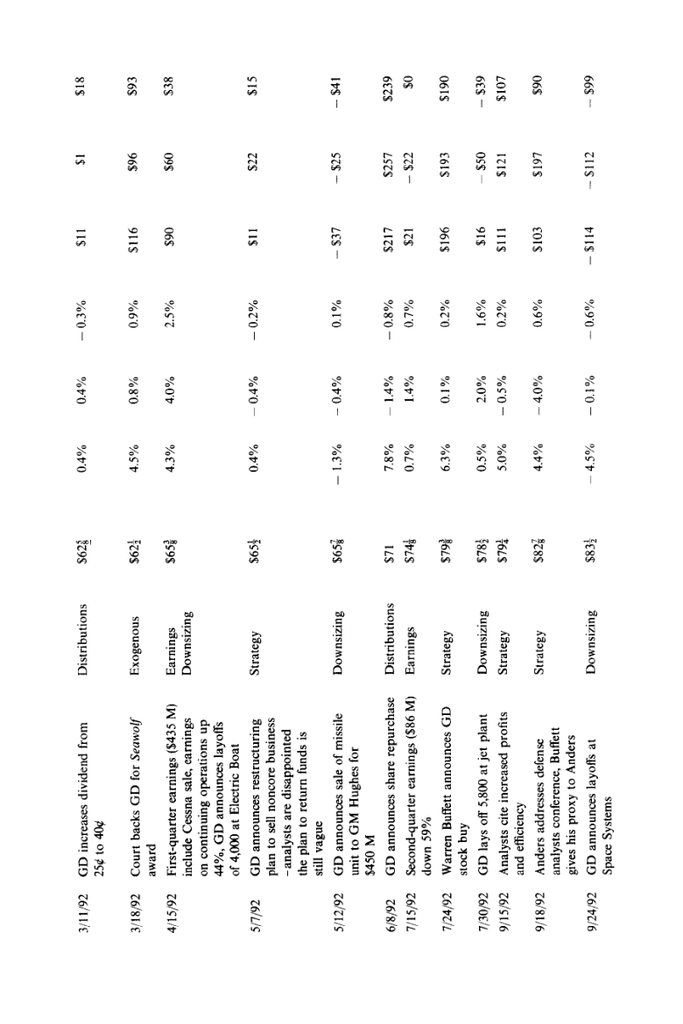

NOTE: Page 51 has no extractable text layer; it is shown as an image of the PDF page. Text on this page cannot be searched.

Page 52

Date Event

10/7/92

10/13/92

10/16/92

10/20/92

10/27/92

1219192

l/27/93

3119193

3130193

4121193

Conferees clear defense budget

-GD benefits as defense

priorities change

GD to sell electronics unit to

Carlyle Group

GD gets 81.5 B tank sale

Thirdquarter earnings ($120 M)

up 70%

GD lays off 1680 at Convair,

40% of work force

Rumors of safe of jet business

to Lockheed

GD announces sale of jets to

Lockheed

Fourth-quarter earnings

($174 h@ up 5%

GD announces $20 special

dividend, Anders and two

other top officers resign

Exdividend date for $20 special

dividend

Firstquarter earnings ($687 M)

up 58%

[output not shown]

NOTE: table converted from PDF layout to HTML text; cell boundaries are reconstructed. See PDF if exact alignment matters.

Exogenous $884

Downsizing %9&

Exogenous

Earnings

Downsizing

Downsizing

Downsizing

Earnings $115

Distributions $118f

Distributions $984

Earnings $974

Page 53

6115193

l/21/93

8/30/93

9116193

9122193

10/20/93

12123193

l/26/94

318194

GD announces $18 special

dividend

Ex-dividend date for $18 special

dividend

Second-quarter earnings ($61 M)

down 29%, but exceed

analysts’ estimates

GD lays off 700 more at tank

plant

CD announces $12 special

dividend, increases dividend

from 40# to 60$

Ex-dividend date for $12 special

dividend

Third-quarter earnings ($73 M)

down 39%

GD sells Space Systems to

Martin Marietta

Fourth-quarter earnings

($62 M) down 64%

Anders steps down as Chairman

Distributions

Distributions

Earnings

Downsizing

Distributions

Distributions

Earnings

Downsizing

Earnings

SSG 1.6%

%9@ 2.3%

$94; 0.4%

S99+ 3.1%

%9c+ 5.1%

$956 ~ 3.0%

[output not shown]

NOTE: table converted from PDF layout to HTML text; cell boundaries are reconstructed. See PDF if exact alignment matters.

rs91; 1.8%

$92 - 2.6%

$57

$46

$71

- $5

$100

$139

-$71

$10

$19

- $93

“Three-day returns and value changes include one day before and one day after the start and finish dates listed for the Gulf War period and the Soviet coup.

Page 54

References

Baker, George P., 1990, Pay for performance for middle managers: Causes and consequences,

Journal of Applied Corporate Finance 3, no. 3. Baker, George P., Michael C. Jensen, and Kevin J. Murphy, 1988, Compensation and incentives:

Practice vs. theory, Journal of Finance, July. Black, Fischer and Myron Scholes, 1973, The pricing of options and corporate liabilities, Journal of

Political Economy 81, no. 3. Campbell, Cynthia J. and Charles E. Wasley, 1994, Executive compensation: The case of Ralston

Purina Company (Washington University, St. Louis, MO). Crystal, Graef S. and Fred K. Foulkes, 1988, Don’t bail out underwater options, Fortune, March 14. DeAngelo, Harry and Linda DeAngelo, 1991, Union negotiation and corporate policy: A study

of labor concessions in the domestic steel industry during the 1980s Journal of Financial Economics 30, no. 1. Dechow, Patricia, Mark Huson, and Richard Sloan, 1994, The effect of restructuring charges on

executives’ cash compensation, Accounting Review 69, no. 1. Gaver, Jennifer J. and Kenneth M. Gaver, 1993, Additional evidence on the association between the

investment opportunity set and corporate financing, dividend, and compensating policies, Journal of Accounting and Economics 16, no. l-3. Goyal, Vidhan, Kenneth Lehn, and Stank0 Racic, 1993, Investment opportunities, corporate finance, and compensation policy in the U.S. defense industry (University of Pittsburgh, Pittsburgh, PA). Healy, Paul, 1985, The effect of bonus schemes on accounting decisions, Journal of Accounting and

Economics 7, no. l-3. Jensen, Michael C., 1986, Agency costs of free cash flow: Corporate finance and takeovers, American

Economic Review 76, no. 2. Jensen, Michael C., 1989, Eclipse of the public corporation, Harvard Business Review, Sept./Ott. Jensen, Michael C.; 1991, Corporate control and the politics of finance, Journal of Applied Corporate Finance, Summer. Jensen, Michael C., 1993, The modern industrial revolution, exit, and the failure of internal control

systems, Journal of Finance 48, no. 3. Jensen, Michael C. and Kevin J. Murphy, 1990a, Performance pay and top-management incentives,

Journal of Political Economy 98, no. 2. Jensen, Michael C. and Kevin J. Murphy, 1990b, A new survey of executive compensation: Full

survey and technical appendix, Working paper 90-067 (Harvard Business School, Boston, MA). Lundquist, Jerrold T., 1992, Shrink fast and smart in the defense industry, Harvard Business Review,

Nov./Dee. Minnich, Richard T., 1993, U.S. defense industry in transition: Can the leopard change its spots?,

Business Forum, Winter/Spring. Murphy, Kevin J., 1993, Executive compensation in corporate America (United Shareholders

Association, Washington, DC). Murphy, Kevin J. and Jay Dial, 1993, General Dynamics: Compensation and strategy, (A) and (B),

HBS case nos. 9-494-048 and 9-494-049 (Harvard Business School, Boston, MA). Rosen, Sherwin, 1982, Authority, control, and the distribution of earnings, Bell Journal of Eco- nomics 13, no. 2. Smale, John, 1989, Takeovers and the public interest, The Corporate Board, Sept./Ott.

Smith, Clifford W. and Ross L. Watts, 1992, The investment opportunity set and corporate financing, dividend, and compensation policies, Journal of Financial Economics 32, no. 3. Stewart, G. Bennett, 1991, The quest for value: A guide for senior managers (HarperCollins

Publishers, New York, NY).